# Group 2 Analysis: 10-100 locations

### pivot

```r
dataRU <- dataRU[c("country", "location","week", "vperc", "measure", "value", "cbin", "nbin")]%>%
  pivot_longer(cols = c("cbin", "nbin"), names_to = "bins", values_to = "binvalue")
```

#### test plot

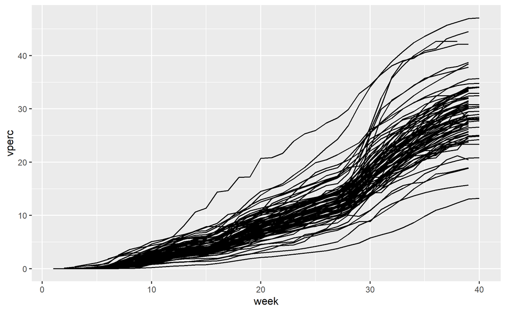

```r
plot <- dataRU %>%
  ggplot(aes(x = week, y = vperc, group = location)) + geom_line()
plot
```

### grid summary

computing average of location and bin, for H-L summaries

```r
gridRU <- dataRU %>%
  group_by(country, week, measure, bins, binvalue) %>%
  summarise(avg = mean(vperc)) %>%
  ungroup()
```

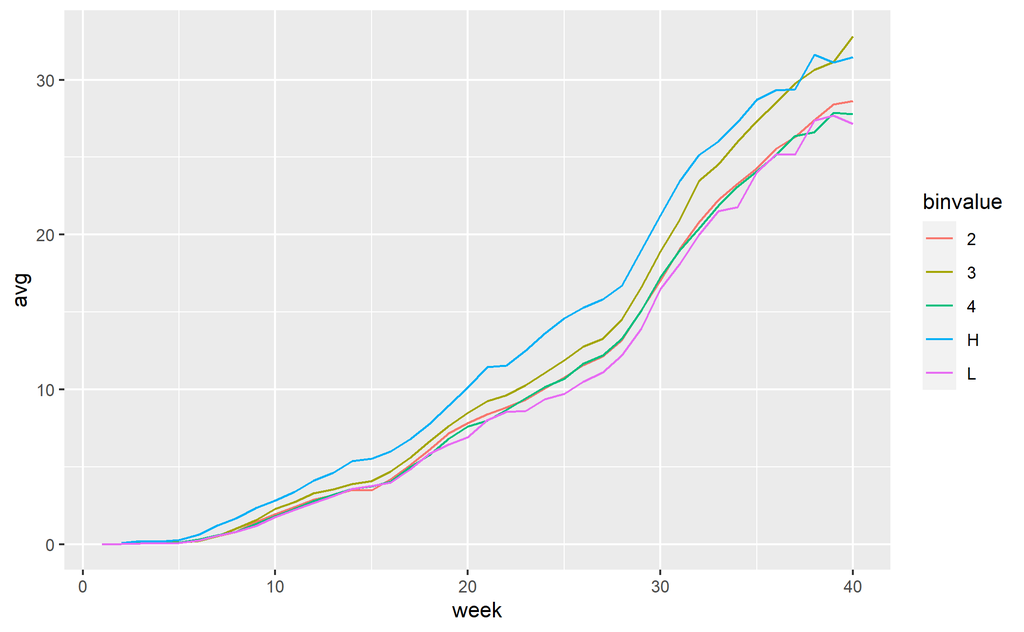

```r
plot <- gridRU %>%
  filter(bins == "nbin") %>%
  ggplot(aes(x = week, y = avg, group = binvalue, color = binvalue)) + geom_line()
plot
```

## SPAIN

### merge

```r
dataSP1 <- dataSP1 %>%
  rename(location = 3) %>%
  mutate(vperc = 100*vcum/pop)


dataSP <- inner_join(dataSP1, dataSP2, by = c("country", "location"))
```

### date to week

Vaccination started Dec 27 2020 https://en.wikipedia.org/wiki/COVID-19_vaccination_in_Spain

```r
start <- c("2020-12-27")

dataSP <- dataSP %>%
  mutate(week = difftime(date, as.Date(start, "%Y-%m-%d"), units = "weeks")) %>%
  mutate( week = gsub(" weeks", "", week)) %>%
  mutate(week = as.integer(week)) %>%
  group_by(location, week) %>%
  ## here we pick the max date in a week for a location, and filter out to just get the data for that date (i.e., we are pulling the most recent vperc for the week).
  filter(date == max(date, na.rm = T)) %>%
  ungroup() %>%
  mutate(date = NULL) %>%
  filter(!all(is.na(vperc)), !is.na(value))
```

### bin SES

```r
## 19 locations, income2 - disposable income
sesSP <- dataSP[c("location", "measure", "value")] %>%
  distinct() %>%
  filter(measure == "income2") %>%
  mutate(nbin = ntile(x= value, n = 3)) %>%
  mutate(cbin = cut_interval(value, n = 3, labels = c("L",2,"H"), na.rm = T))

  sesSP$nbin[sesSP$nbin == 1] <- "L"
  sesSP$nbin[sesSP$nbin == 3] <- "H"

dataSP <- dataSP %>%
  left_join(sesSP, by = c("location", "measure", "value")) %>%
  group_by(location) %>%
  filter(!is.na(value), !all(is.na(vperc))) %>%
  ungroup() %>%
  mutate(country = "Spain")

  dataSP$measure[dataSP$measure == "income2"] <- "income"
```

### pivot

```r
dataSP <- dataSP[c("country", "location","week", "vperc", "measure", "value", "cbin", "nbin")]%>%
  pivot_longer(cols = c("cbin", "nbin"), names_to = "bins", values_to = "binvalue")
```

#### test plot

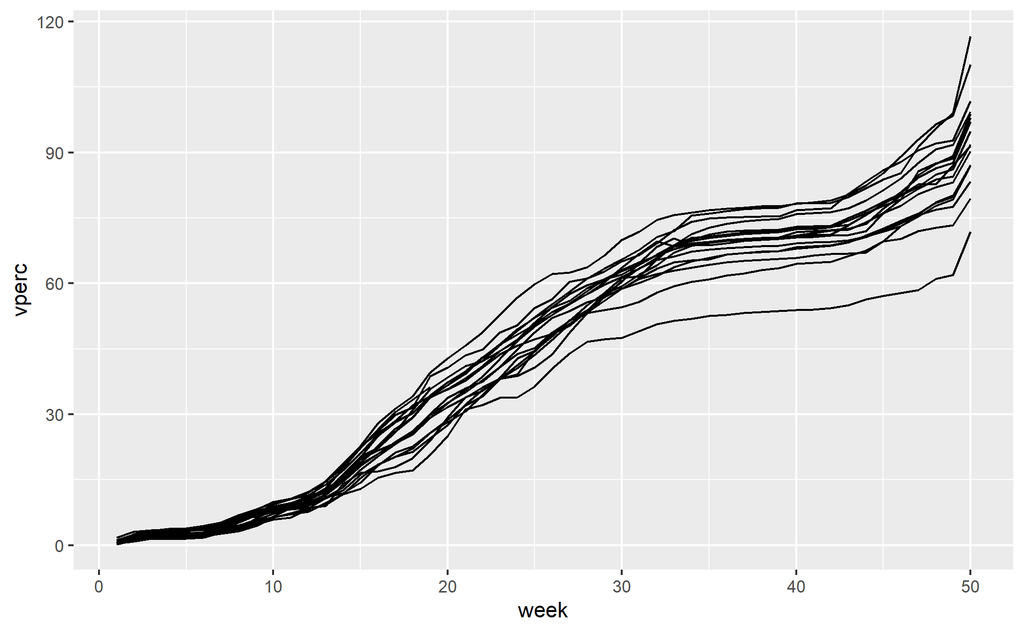

```r
plot <- dataSP %>%
  ggplot(aes(x = week, y = vperc, group = location)) + geom_line()
plot
```

### grid summary

computing average of location and bin, for H-L summaries

```r
gridSP <- dataSP %>%
  group_by(country, week, measure, bins, binvalue) %>%
  summarise(avg = mean(vperc)) %>%
  ungroup()
```

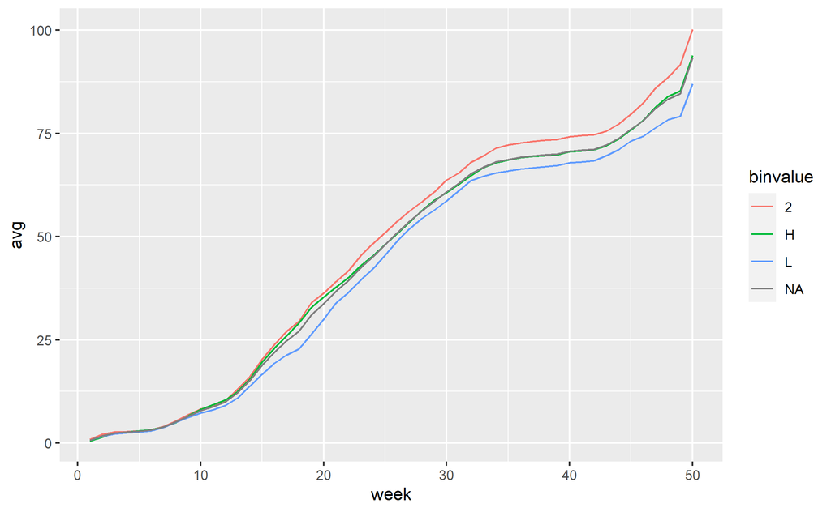

```r
plot <- gridSP %>%
  filter(bins == "nbin") %>%
  ggplot(aes(x = week, y = avg, group = binvalue, color = binvalue)) + geom_line()
plot
```

## SWEDEN

### merge

```r
dataSW1 <- dataSW1 %>%
  rename(location = 3) %>%
  mutate(vperc = 100*vcum/pop)


dataSW <- inner_join(dataSW1, dataSW2, by = c("country", "location"))
```

### date to week

Vaccination started Dec 27 2020 https://en.wikipedia.org/wiki/COVID-19_vaccination_in_Sweden

```r
start <- c("2020-12-27")

dataSW <- dataSW %>%
  mutate(week = difftime(date, as.Date(start, "%Y-%m-%d"), units = "weeks")) %>%
  mutate( week = gsub(" weeks", "", week)) %>%
  mutate(week = as.integer(week)) %>%
  group_by(location, week) %>%
  ## here we pick the max date in a week for a location, and filter out to just get the data for that date (i.e., we are pulling the most recent vperc for the week).
  filter(date == max(date, na.rm = T)) %>%
  ungroup() %>%
  mutate(date = NULL) %>%
  filter(!all(is.na(vperc)), !is.na(value))
```

### bin SES

```r
## 21 locations, income6 - at risk of poverty rate
sesSW <- dataSW[c("location", "measure", "value")] %>%
  distinct() %>%
  filter(measure == "income6") %>%
  mutate(nbin = ntile(x= value, n = 5)) %>%
  mutate(cbin = cut_interval(value, n = 5, labels = c("H",2,3,4,"L"), na.rm = T))

  sesSW$nbin[sesSW$nbin == 1] <- "H"
  sesSW$nbin[sesSW$nbin == 5] <- "L"

dataSW <- dataSW %>%
  left_join(sesSW, by = c("location", "measure", "value")) %>%
  group_by(location) %>%
  filter(!is.na(value), !all(is.na(vperc))) %>%
  ungroup() %>%
  mutate(country = "Sweden")

  dataSW$measure[dataSW$measure == "income6"] <- "poverty"
```

### pivot

```r
dataSW <- dataSW[c("country", "location","week", "vperc", "measure", "value", "cbin", "nbin")]%>%
  pivot_longer(cols = c("cbin", "nbin"), names_to = "bins", values_to = "binvalue")
```

#### test plot

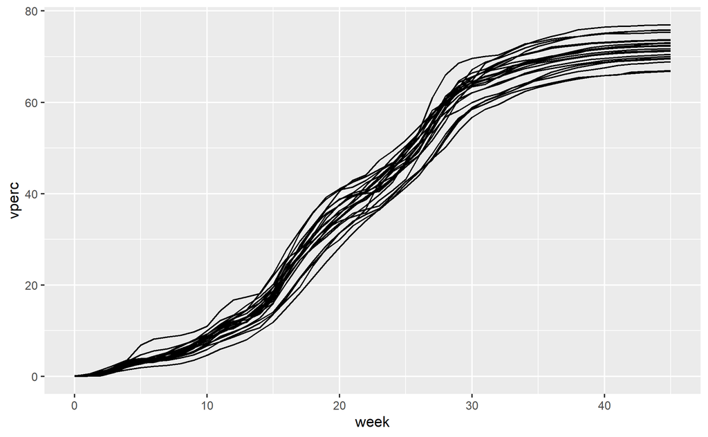

```r
plot <- dataSW %>%
  ggplot(aes(x = week, y = vperc, group = location)) + geom_line()
plot
```

### grid summary

computing average of location and bin, for H-L summaries

```r
gridSW <- dataSW %>%
  group_by(country, week, measure, bins, binvalue) %>%
  summarise(avg = mean(vperc)) %>%
  ungroup()
```

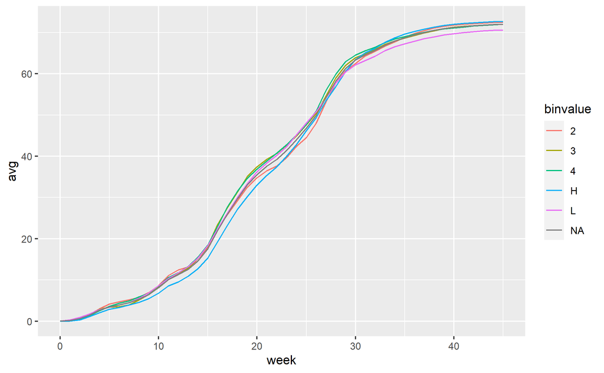

```r
plot <- gridSW %>%
  filter(bins == "nbin") %>%
  ggplot(aes(x = week, y = avg, group = binvalue, color = binvalue)) + geom_line()
plot
```

## DENMARK

### date to week

Vaccination started Dec 27 2020 https://www.regioner.dk/sundhed/coronaviruscovid-19/vaccination-mod-covid-19/the-danish-covid-19-vaccination-programme

```r
start <- c("2020-12-27")

dataDK <- dataDK %>%
  mutate(week = difftime(date, as.Date(start, "%Y-%m-%d"), units = "weeks")) %>%
  mutate( week = gsub(" weeks", "", week)) %>%
  mutate(week = as.integer(week)) %>%
  group_by(location, week) %>%
  ## here we pick the max date in a week for a location, and filter out to just get the data for that date (i.e., we are pulling the most recent vperc for the week).
  filter(date == max(date, na.rm = T)) %>%
  ungroup() %>%
  mutate(date = NULL) %>%
  filter(!all(is.na(vperc)), !is.na(value))
```

### bin SES

```r
## 98 locations, income
sesDK <- dataDK[c("location", "measure", "value")] %>%
  distinct() %>%
  mutate(nbin = ntile(x= value, n = 5)) %>%
  mutate(cbin = cut_interval(value, n = 5, labels = c("L",2,3,4,"H"), na.rm = T))

  sesDK$nbin[sesDK$nbin == 1] <- "L"
  sesDK$nbin[sesDK$nbin == 5] <- "H"

dataDK <- dataDK %>%
  left_join(sesDK, by = c("location", "measure", "value")) %>%
  group_by(location) %>%
  filter(!is.na(value), !all(is.na(vperc))) %>%
  ungroup() %>%
  mutate(country = "Denmark")
```

### pivot

```r
dataDK <- dataDK[c("country", "location","week", "vperc", "measure", "value", "cbin", "nbin")]%>%
  pivot_longer(cols = c("cbin", "nbin"), names_to = "bins", values_to = "binvalue")
```

#### test plot

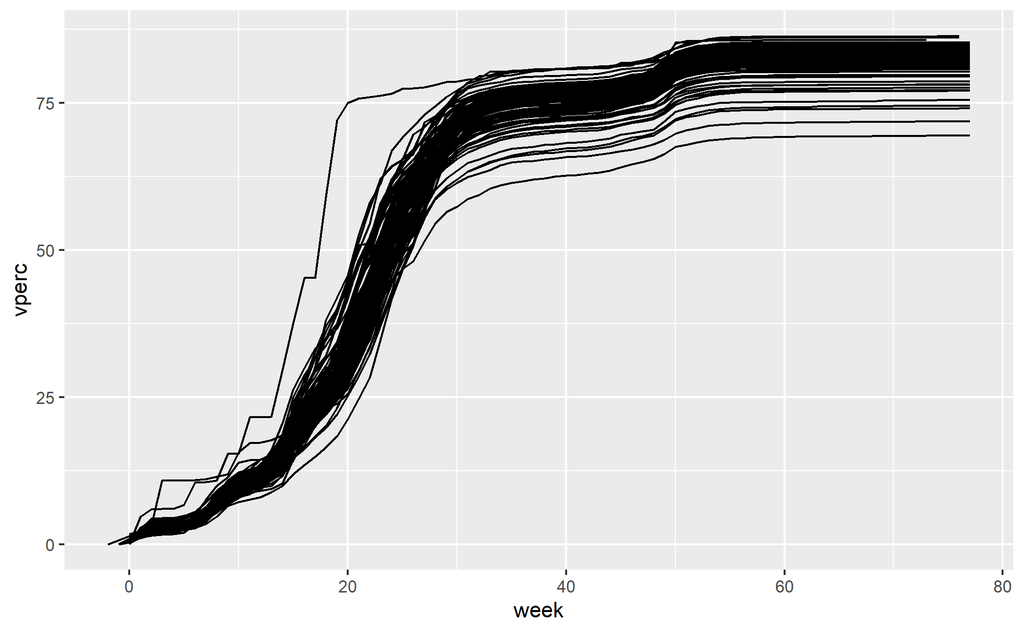

```r
plot <- dataDK %>%
  ggplot(aes(x = week, y = vperc, group = location)) + geom_line()
plot
```

### grid summary

computing average of location and bin, for H-L summaries

```r
gridDK <- dataDK %>%
  group_by(country, week, measure, bins, binvalue) %>%
  summarise(avg = mean(vperc)) %>%
  ungroup()
```

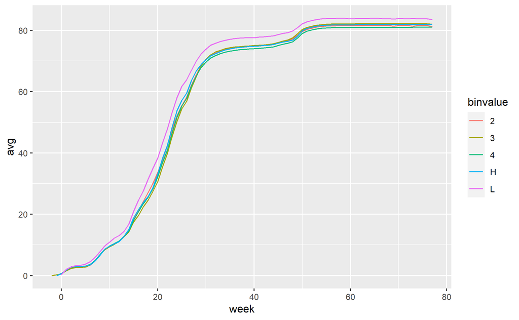

```r
plot <- gridDK %>%
  filter(bins == "nbin") %>%
  ggplot(aes(x = week, y = avg, group = binvalue, color = binvalue)) + geom_line()
plot
```

## NORWAY

### date to week

Vaccination started 27 Dec 2020 https://lexatlas-c19.org/norway-voluntary-vaccination-is-the-policy-law-allows-for-more-but-probably-not-now/

Vaccination in Svalbard was slow going, with 54-65 eligible in March 2021 https://www.thestar.com/news/insight/2021/03/13/the-remotest-luck.html

```r
start <- c("2020-12-27")

dataNO <- dataNO %>%
  mutate(week = difftime(date, as.Date(start, "%Y-%m-%d"), units = "weeks")) %>%
  mutate( week = gsub(" weeks", "", week)) %>%
  mutate(week = as.integer(week)) %>%
 group_by(location, week) %>%
  ## here we pick the max date in a week for a location, and filter out to just get the data for that date (i.e., we are pulling the most recent vperc for the week).
  filter(date == max(date, na.rm = T)) %>%
  ungroup() %>%
  mutate(date = NULL)
```

### vperc

```r
dataNO <- dataNO %>%
  mutate(vperc = 100*vcum/pop) %>%
  filter(!all(is.na(vperc)), !is.na(value))
```

### bin SES

```r
## 12 locations, income
sesNO <- dataNO[c("location", "measure", "value")] %>%
  distinct() %>%
  mutate(nbin = ntile(x= value, n = 3)) %>%
  mutate(cbin = cut_interval(value, n = 3, labels = c("L",2,"H"), na.rm = T))

  sesNO$nbin[sesNO$nbin == 1] <- "L"
  sesNO$nbin[sesNO$nbin == 3] <- "H"

dataNO <- dataNO %>%
  left_join(sesNO, by = c("location", "measure", "value")) %>%
  group_by(location) %>%
  filter(!is.na(value), !all(is.na(vperc))) %>%
  ungroup() %>%
  mutate(country = "Norway")
```

### pivot

```r
dataNO <- dataNO[c("country", "location","week", "vperc", "measure", "value", "cbin", "nbin")]%>%
  pivot_longer(cols = c("cbin", "nbin"), names_to = "bins", values_to = "binvalue")
```

#### test plot

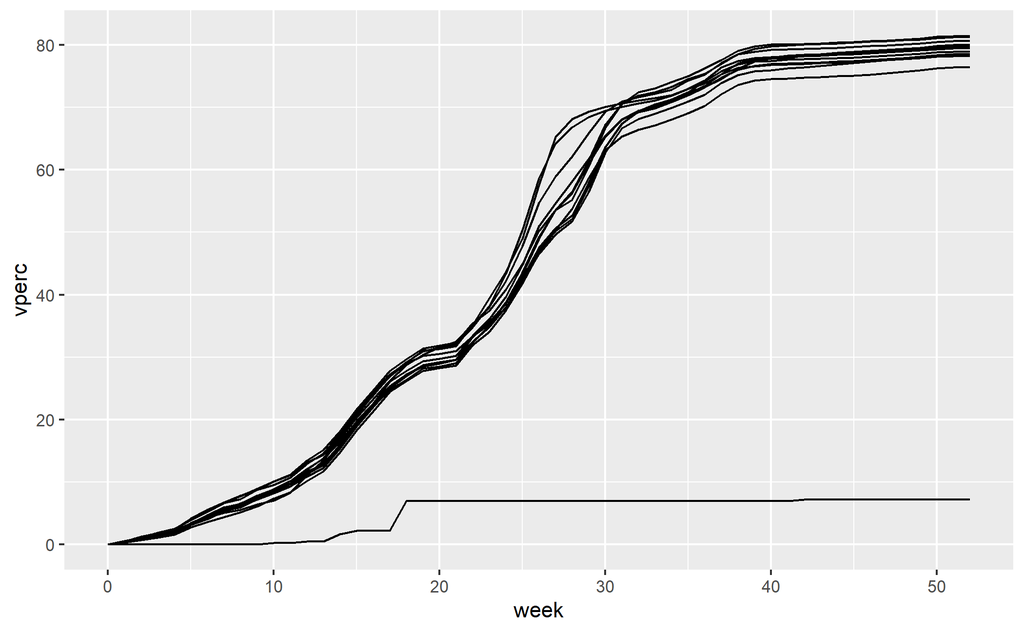

```r
plot <- dataNO %>%
  ggplot(aes(x = week, y = vperc, group = location)) + geom_line()
plot
```

### grid summary

computing average of location and bin, for H-L summaries

```r
gridNO <- dataNO %>%
  group_by(country, week, measure, bins, binvalue) %>%
  summarise(avg = mean(vperc)) %>%
  ungroup()
```

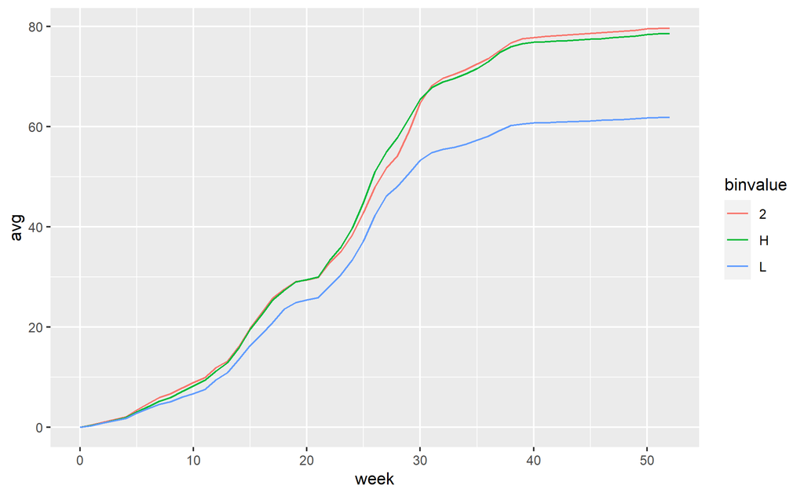

```r
plot <- gridNO %>%
  filter(bins == "nbin") %>%
  ggplot(aes(x = week, y = avg, group = binvalue, color = binvalue)) + geom_line()
plot
```

## CABO VERDE

### date to week

Vaccination started approx 18 March 2021 https://covid19.cv/primeiras-vacinas-contra-covid-19-administradas-em-cabo-verde/

```r
start <- c("2021-03-18")

dataCV <- dataCV %>%
  mutate(week = difftime(date, as.Date(start, "%Y-%m-%d"), units = "weeks")) %>%
  mutate( week = gsub(" weeks", "", week)) %>%
  mutate(week = as.integer(week)) %>%
  group_by(location, week) %>%
  ## here we pick the max date in a week for a location, and filter out to just get the data for that date (i.e., we are pulling the most recent vperc for the week).
  filter(date == max(date, na.rm = T)) %>%
  ungroup() %>%
  mutate(date = NULL)
```

### vperc

```r
dataCV <- dataCV %>%
  mutate(vperc = 100*vcum/pop) %>%
  filter(!all(is.na(vperc)), !is.na(value))
```

### bin SES

```r
## 22 locations, poverty
sesCV <- dataCV[c("location", "measure", "value")] %>%
  distinct() %>%
  mutate(nbin = ntile(x= value, n = 5)) %>%
  mutate(cbin = cut_interval(value, n = 5, labels = c("H",2,3,4,"L"), na.rm = T))

  sesCV$nbin[sesCV$nbin == 1] <- "H"
  sesCV$nbin[sesCV$nbin == 5] <- "L"

dataCV <- dataCV %>%
  left_join(sesCV, by = c("location", "value", "measure")) %>%
  group_by(location) %>%
  filter(!is.na(value), !all(is.na(vperc))) %>%
  ungroup() %>%
  mutate(country = "Cape Verde")
```

### pivot

```r
dataCV <- dataCV[c("country", "location","week", "vperc", "measure", "value", "cbin", "nbin")]%>%
  pivot_longer(cols = c("cbin", "nbin"), names_to = "bins", values_to = "binvalue")
```

#### test plot

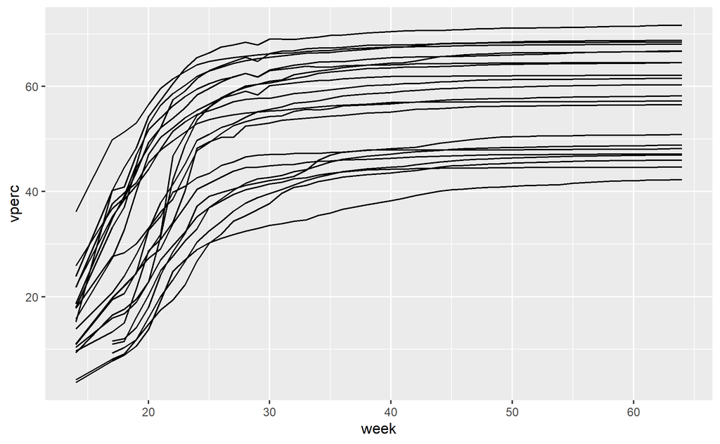

```r
plot <- dataCV %>%
  ggplot(aes(x = week, y = vperc, group = location)) + geom_line()
plot
```

### grid summary

computing average of location and bin, for H-L summaries

```r
gridCV <- dataCV %>%
  group_by(country, week, measure, bins, binvalue) %>%
  summarise(avg = mean(vperc)) %>%
  ungroup()
```

## PALESTINE

### merge

```r
dataPal <- inner_join(dataPal1, dataPal2)
```

### date to week

```r
start <- c("2021-03-30")

dataPal <- dataPal %>%
  mutate(week = difftime(date, as.Date(start, "%Y-%m-%d"), units = "weeks")) %>%
  mutate( week = gsub(" weeks", "", week)) %>%
  mutate(week = as.integer(week)) %>%
  group_by(location, week) %>%
  ## here we pick the max date in a week for a location, and filter out to just get the data for that date (i.e., we are pulling the most recent vperc for the week).
  filter(date == max(date, na.rm = T)) %>%
  ungroup() %>%
  mutate(date = NULL) %>%
  filter(!all(is.na(vperc)), !is.na(value))
```

### bin SES

```r
## 12 locations, daily wages
sesPal <- dataPal[c("location", "measure", "value")] %>%
  distinct() %>%
  mutate(nbin = ntile(x= value, n = 3)) %>%
  mutate(cbin = cut_interval(value, n = 3, labels = c("L",2,"H"), na.rm = T))

  sesPal$nbin[sesPal$nbin == 1] <- "L"
  sesPal$nbin[sesPal$nbin == 3] <- "H"

dataPal <- dataPal %>%
  left_join(sesPal, by = c("location", "measure", "value")) %>%
  group_by(location) %>%
  filter(!is.na(value), !all(is.na(vperc))) %>%
  ungroup() %>%
  mutate(country = "Palestine")
```

### pivot

```r
dataPal <- dataPal[c("country", "location","week", "vperc", "measure", "value", "cbin", "nbin")]%>%
  pivot_longer(cols = c("cbin", "nbin"), names_to = "bins", values_to = "binvalue")
```

#### test plot

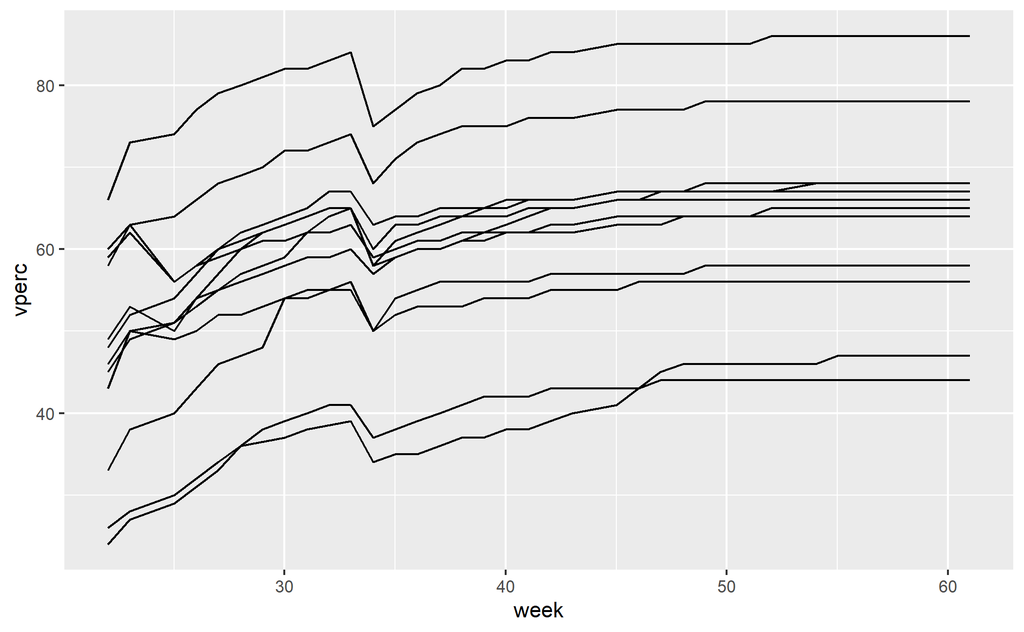

```r
plot <- dataPal %>%
  ggplot(aes(x = week, y = vperc, group = location)) + geom_line()
plot
```

### grid summary

computing average of location and bin, for H-L summaries

```r
gridPal <- dataPal %>%
  group_by(country, week, measure, bins, binvalue) %>%
  summarise(avg = mean(vperc)) %>%
  ungroup()
```

## CZECH REPUBLIC

### date to week

Vaccination started approx 27 Dec 2020 https://www.reuters.com/business/healthcare-pharmaceuticals/czech-republic-starts-rollout-coronavirus-vaccine-2020-12-27/

```r
start <- c("2020-12-27")

dataCZ <- dataCZ %>%
  mutate(week = difftime(date, as.Date(start, "%Y-%m-%d"), units = "weeks")) %>%
  mutate( week = gsub(" weeks", "", week)) %>%
  mutate(week = as.integer(week)) %>%
  group_by(location, week) %>%
  ## here we pick the max date in a week for a location, and filter out to just get the data for that date (i.e., we are pulling the most recent vperc for the week).
  filter(date == max(date, na.rm = T)) %>%
  ungroup() %>%
  mutate(date = NULL)
```

### vperc

```r
dataCZ <- dataCZ %>%
  mutate(vperc = 100*vcum/pop)%>%
  filter(!all(is.na(vperc)), !is.na(value))
```

### bin SES

```r
## 14 locations, GDP pc
sesCZ <- dataCZ[c("location", "measure", "value")] %>%
  distinct() %>%
  mutate(nbin = ntile(x= value, n = 3)) %>%
  mutate(cbin = cut_interval(value, n = 3, labels = c("L",2,"H"), na.rm = T))

  sesCZ$nbin[sesCZ$nbin == 1] <- "L"
  sesCZ$nbin[sesCZ$nbin == 3] <- "H"

dataCZ <- dataCZ %>%
  left_join(sesCZ, by = c("location", "measure", "value")) %>%
  group_by(location) %>%
  filter(!is.na(value), !all(is.na(vperc))) %>%
  ungroup() %>%
  mutate(country = "Czech Republic")
```

### pivot

```r
dataCZ <- dataCZ[c("country", "location","week", "vperc", "measure", "value", "cbin", "nbin")]%>%
  pivot_longer(cols = c("cbin", "nbin"), names_to = "bins", values_to = "binvalue")
```

#### test plot

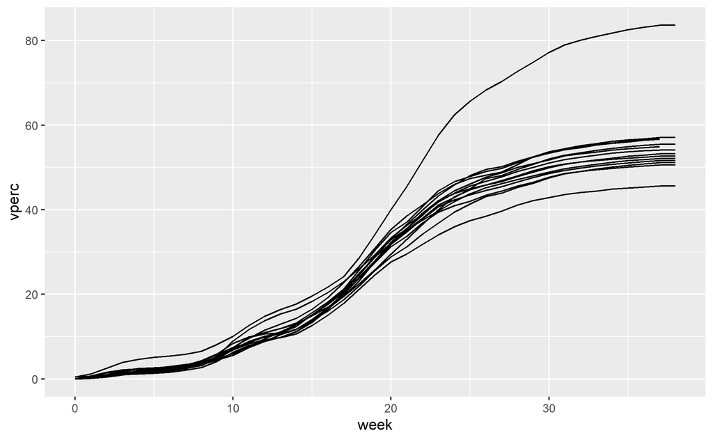

```r
plot <- dataCZ %>%
  ggplot(aes(x = week, y = vperc, group = location)) + geom_line()
plot
```

### grid summary

computing average of location and bin, for H-L summaries

```r
gridCZ <- dataCZ %>%
  group_by(country, week, measure, bins, binvalue) %>%
  summarise(avg = mean(vperc)) %>%
  ungroup()
```

## ARGENTINA

### date to week

Vaccination started on 29 Dec 2020 https://en.wikipedia.org/wiki/COVID-19_vaccination_in_Argentina

```r
start <- c("2020-12-29")

dataAr <- dataAr %>%
  mutate(week = difftime(date, as.Date(start, "%Y-%m-%d"), units = "weeks")) %>%
  mutate( week = gsub(" weeks", "", week)) %>%
  mutate(week = as.integer(week)) %>%
  group_by(location, week) %>%
  ## here we pick the max date in a week for a location, and filter out to just get the data for that date (i.e., we are pulling the most recent vperc for the week).
  filter(date == max(date, na.rm = T)) %>%
  ungroup() %>%
  mutate(date = NULL)
```

### vperc

```r
dataAr <- dataAr %>%
  mutate(vperc = 100*vcum/pop)%>%
  filter(!all(is.na(vperc)), !is.na(value))
```

### bin SES

```r
## more than 20 locations, income measure
sesAr <- dataAr[c("location", "measure", "value")] %>%
  distinct() %>%
  mutate(nbin = ntile(x= value, n = 5)) %>%
  mutate(cbin = cut_interval(value, n = 5, labels = c("L",2,3,4,"H"), na.rm = T))

  sesAr$nbin[sesAr$nbin == 1] <- "L"
  sesAr$nbin[sesAr$nbin == 5] <- "H"

dataAr <- dataAr %>%
  left_join(sesAr, by = c("location", "measure", "value")) %>%
  group_by(location) %>%
  filter(!is.na(value), !all(is.na(vperc))) %>%
  ungroup() %>%
  mutate(country = "Argentina")
```

### pivot

```r
dataAr <- dataAr[c("country", "location","week", "vperc", "measure", "value", "cbin", "nbin")]%>%
  pivot_longer(cols = c("cbin", "nbin"), names_to = "bins", values_to = "binvalue")
```

#### test plot

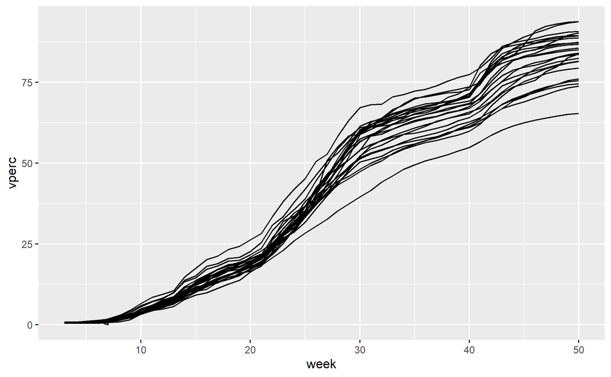

```r
plot <- dataAr %>%
  ggplot(aes(x = week, y = vperc, group = location)) + geom_line()
plot
```

### grid summary

computing average of location and bin, for H-L summaries

```r
gridAr <- dataAr %>%
  group_by(country, week, measure, bins, binvalue) %>%
  summarise(avg = mean(vperc)) %>%
  ungroup()
```

## ISRAEL

### date to week

They started vaccinating on December 20 https://ijhpr.biomedcentral.com/articles/10.1186/s13584-021-00440-6

```r
start <- c("2020-12-20")

dataIs <- dataIs %>%
  mutate(week = difftime(date, as.Date(start, "%Y-%m-%d"), units = "weeks")) %>%
  mutate( week = gsub(" weeks", "", week)) %>%
  mutate(week = as.integer(week)) %>%
group_by(location, week) %>%
  ## here we pick the max date in a week for a location, and filter out to just get the data for that date (i.e., we are pulling the most recent vperc for the week).
  filter(date == max(date, na.rm = T)) %>%
  ungroup() %>%
  mutate(date = NULL) %>%
  filter(week >= 0)
```

### vperc

```r
dataIs <- dataIs %>%
  mutate(vperc = 100*vcum/pop)%>%
  filter(!all(is.na(vperc)), !is.na(value))
```

### bin SES

```r
## we have >20 locations
sesIs <- dataIs[c("location", "measure", "value")] %>%
  distinct() %>%
  ## income
  mutate(nbin = ntile(x= value, n = 5)) %>%
  mutate(cbin = cut_interval(value, n = 5, labels = c("L",2,3,4,"H"), na.rm = T))

  sesIs$nbin[sesIs$nbin == 5] <- "H"
  sesIs$nbin[sesIs$nbin == 1] <- "L"

dataIs <- dataIs %>%
  left_join(sesIs, by = c("location", "value", "measure")) %>%
  group_by(location) %>%
  filter(!is.na(value), !all(is.na(vperc))) %>%
  ungroup() %>%
  mutate(country = "Israel")
```

### pivot

```r
dataIs <- dataIs[c("country", "location","week", "vperc", "measure", "value", "cbin", "nbin")]%>%
  pivot_longer(cols = c("cbin", "nbin"), names_to = "bins", values_to = "binvalue")
```

### grid summary

computing average of location and bin, for H-L summaries

```r
gridIs <- dataIs %>%
  group_by(country, week, measure, bins, binvalue) %>%
  summarise(avg = mean(vperc)) %>%
  ungroup()
```

## KAZAKHSTAN

### date to week

They started the mass vaccination campaign on Feb 1 2021 http://www.xinhuanet.com/english/2021-02/02/c_139713832.htm

```r
start <- c("2021-02-01")

dataKa <- dataKa %>%
  mutate(week = difftime(date, as.Date(start, "%Y-%m-%d"), units = "weeks")) %>%
  mutate( week = gsub(" weeks", "", week)) %>%
  mutate(week = as.integer(week)) %>%
group_by(location, week) %>%
  ## here we pick the max date in a week for a location, and filter out to just get the data for that date (i.e., we are pulling the most recent vperc for the week).
  filter(date == max(date, na.rm = T)) %>%
  ungroup() %>%
  mutate(date = NULL)
```

### vperc

```r
dataKa <- dataKa %>% mutate(vperc = 100*vcum/population)%>%
  filter(!all(is.na(vperc)), !is.na(value))
```

### bin SES

```r
## we have <20 locations
sesKa <- dataKa[c("location", "measure", "value")] %>%
  distinct() %>%
  ## poverty measure
  mutate(nbin = ntile(x= value, n = 3)) %>%
  mutate(cbin = cut_interval(value, n = 3, labels = c("H",2,"L"), na.rm = T))

  sesKa$nbin[sesKa$nbin == 1] <- "H"
  sesKa$nbin[sesKa$nbin == 3] <- "L"

dataKa <- dataKa %>%
  left_join(sesKa, by = c("location", "measure", "value")) %>%
  group_by(location) %>%
  filter(!is.na(value), !all(is.na(vperc))) %>%
  ungroup() %>%
  mutate(country = "Kazakhstan")
```

### pivot

```r
dataKa <- dataKa[c("country", "location","week", "vperc", "measure", "value", "cbin", "nbin")]%>%
  pivot_longer(cols = c("cbin", "nbin"), names_to = "bins", values_to = "binvalue")
```

### grid summary

computing average of location and bin, for H-L summaries

```r
gridKa <- dataKa %>%
  group_by(country, week, measure, bins, binvalue) %>%
  summarise(avg = mean(vperc)) %>%
  ungroup()
```

## ITALY

### date to week

Vaccination started December 27, 2020 https://en.wikipedia.org/wiki/COVID-19_vaccination_in_Italy

```r
start <- c("2020-12-27")

dataIT1 <- dataIT1 %>%
  mutate(week = difftime(date, as.Date(start, "%Y-%m-%d"), units = "weeks")) %>%
  mutate( week = gsub(" weeks", "", week)) %>%
  mutate(week = as.integer(week))

dataIT1 <- dataIT1 %>% filter(!is.na(week)) %>%
  group_by(week, location, pop) %>%
  summarise(vnum = sum(vnum, na.rm = T)) %>%
  ungroup() %>%
  arrange(week) %>%
  group_by(location) %>%
  mutate(vcum = cumsum(vnum)) %>%
  ungroup()
```

### innerjoin and vperc

```r
dataIT <- inner_join(dataIT1, dataIT2, by = "location") %>%
  group_by(week, location, value, pop) %>%
  mutate(vperc = 100*vcum/pop) %>%
  ungroup()%>%
  filter(!all(is.na(vperc)), !is.na(value))
```

### bin SES

```r
## we have 21 locations for each SES measure
sesIT <- dataIT[c("location", "measure", "value")] %>%
  distinct() %>%
  ## looking at net wealth per capita, since the others are in billions of dollars - i.e. not scaled by population
  filter(measure == "wealth5") %>%
  mutate(nbin = ntile(x= value, n = 5)) %>%
  mutate(cbin = cut_interval(value, n = 5, labels = c("L",2,3,4,"H"), na.rm = T))

  sesIT$nbin[sesIT$nbin == 5] <- "H"
  sesIT$nbin[sesIT$nbin == 1] <- "L"

dataIT <- dataIT %>%
  left_join(sesIT, by = c("location", "measure", "value")) %>%
  group_by(location) %>%
  filter(!is.na(value), !all(is.na(vperc))) %>%
  ungroup()
```

### pivot

```r
dataIT <- dataIT[c("country", "location","week", "vperc", "measure", "value", "cbin", "nbin")]%>%
  pivot_longer(cols = c("cbin", "nbin"), names_to = "bins", values_to = "binvalue")
```

### grid summary

computing average of location and bin, for H-L summaries

```r
gridIT <- dataIT %>%
  group_by(country, week, measure, bins, binvalue) %>%
  summarise(avg = mean(vperc)) %>%
  ungroup()
```

## COLOMBIA

### date to week

The first vaccine was given Feb 17 2021 https://en.wikipedia.org/wiki/COVID-19_vaccination_in_Colombia This is reflected in the start date of the data

```r
start <- c("2021-02-17")

dataCO1 <- dataCO1 %>%
  mutate(week = difftime(date, as.Date(start, "%Y-%m-%d"), units = "weeks")) %>%
  mutate( week = gsub(" weeks", "", week)) %>%
  mutate(week = as.integer(week))

dataCO1 <- dataCO1 %>% filter(!is.na(week)) %>%
  group_by(week, location) %>%
  summarise(vnum = sum(applied_dose, na.rm = T)) %>%
  ungroup() %>%
  arrange(week) %>%
  group_by(location) %>%
  mutate(vcum = cumsum(vnum)) %>%
  ungroup()
```

### innerjoin and vperc

```r
dataCO <- inner_join(dataCO1, dataCO2, by = "location") %>%
  rename(value = 5, pop = 7) %>%
  group_by(week, location, value, pop) %>%
  summarise(vperc = 100*vcum/pop) %>%
  ungroup() %>%
  add_column(measure = "poverty")%>%
  filter(!all(is.na(vperc)), !is.na(value))
```

### bin SES

```r
sesCO <- dataCO[c("location", "measure", "value")] %>%
  distinct() %>%
  ## poverty measure
  filter(measure == "poverty") %>%
  mutate(nbin = ntile(x= value, n = 5)) %>%
  mutate(cbin = cut_interval(value, n = 5, labels = c("H",2,3,4,"L"), na.rm = T))

  sesCO$nbin[sesCO$nbin == 5] <- "L"
  sesCO$nbin[sesCO$nbin == 1] <- "H"

dataCO <- dataCO %>%
  left_join(sesCO, by = c("location", "measure", "value")) %>%
  group_by(location) %>%
  filter(!is.na(value), !all(is.na(vperc))) %>%
  ungroup()

dataCO <- dataCO %>%
  mutate(country = "Colombia")
```

### pivot

```r
dataCO <- dataCO[c("country", "location","week", "vperc", "measure", "value", "cbin", "nbin")]%>%
  pivot_longer(cols = c("cbin", "nbin"), names_to = "bins", values_to = "binvalue")
```

### grid summary

computing average of location and bin, for H-L summaries

```r
gridCO <- dataCO %>%
  group_by(country, week, measure, bins, binvalue) %>%
  summarise(avg = mean(vperc)) %>%
  ungroup()
```

## FINLAND

date is already in week form

### innerjoin SES and vaccine

```r
dataFI <- inner_join(dataFI1, dataFI2, by = c("location"))%>%
  filter(!all(is.na(vperc)), !is.na(value))
```

### bin SES

```r
sesFI <- dataFI[c("location", "measure", "value")] %>%
  distinct() %>%
  ## social assistance measure
  filter(measure == "value") %>%
  mutate(nbin = ntile(x= value, n = 5)) %>%
  mutate(cbin = cut_interval(value, n = 5, labels = c("H",2,3,4,"L"), na.rm = T))

  sesFI$nbin[sesFI$nbin == 5] <- "L"
  sesFI$nbin[sesFI$nbin == 1] <- "H"

dataFI <- dataFI %>%
  left_join(sesFI, by = c("location", "value", "measure")) %>%
  group_by(location) %>%
  filter(!is.na(value), !all(is.na(vperc))) %>%
  ungroup()

dataFI <- dataFI %>%
  mutate(country = "Finland")
```

### pivot

```r
dataFI <- dataFI[c("country", "location","week", "vperc", "measure", "value", "cbin", "nbin")]%>%
  pivot_longer(cols = c("cbin", "nbin"), names_to = "bins", values_to = "binvalue")
```

### grid summary

computing average of location and bin, for H-L summaries

```r
gridFI <- dataFI %>%
  group_by(country, week, measure, bins, binvalue) %>%
  summarise(avg = mean(vperc)) %>%
  ungroup()
```

## URUGUAY

### date to week

started around March 1, 2021 https://www.aa.com.tr/en/americas/uruguay-last-in-south-america-to-start-vaccination-plan/2161299

```r
start <- c("2021-03-01")

dataUR1 <- dataUR1 %>%
  mutate(week = difftime(date, as.Date(start, "%Y-%m-%d"), units = "weeks")) %>%
  mutate( week = gsub(" weeks", "", week)) %>%
  mutate(week = as.integer(week)) %>%
group_by(location, dose, week) %>%
  ## here we pick the max date in a week for a location, and filter out to just get the data for that date (i.e., we are pulling the most recent vperc for the week).
  filter(date == max(date, na.rm = T)) %>%
  ungroup() %>%
  mutate(date = NULL)
```

### innerjoin SES and vaccine

```r
dataUR <- inner_join(dataUR1, dataUR2, by = c("location"))%>%
  filter(!all(is.na(vperc)), !is.na(value))
```

### bin SES

```r
sesUR <- dataUR[c("location", "measure", "value")] %>%
  distinct() %>%
  filter(measure == "MHI") %>%
  mutate(nbin = ntile(x= value, n = 3)) %>%
  mutate(cbin = cut_interval(value, n = 3, labels = c("L",2,"H"), na.rm = T))

  sesUR$nbin[sesUR$nbin == 1] <- "L"
  sesUR$nbin[sesUR$nbin == 3] <- "H"

dataUR <- dataUR %>%
  left_join(sesUR, by = c("location", "measure", "value")) %>%
  group_by(location) %>%
  filter(!is.na(value), !all(is.na(vperc))) %>%
  ungroup()

dataUR <- dataUR %>%
  mutate(country = "Uruguay")
```

### pivot

```r
dataUR <- dataUR[c("country", "location","week", "vperc", "measure", "value", "cbin", "nbin")]%>%
  pivot_longer(cols = c("cbin", "nbin"), names_to = "bins", values_to = "binvalue")
```

### grid summary

computing average of location and bin, for H-L summaries

```r
gridUR <- dataUR %>%
  group_by(country, week, measure, bins, binvalue) %>%
  summarise(avg = mean(vperc)) %>%
  ungroup()
```

## SWITZERLAND

### date to week

started around 23rd december 2020 https://www.swissinfo.ch/eng/first-vaccines-arrive-in-switzerland--first-jabs-on-wednesday/46240828

```r
start <- c("2020-12-23")

dataSWI1 <- dataSWI1 %>%
  mutate(week = difftime(date, as.Date(start, "%Y-%m-%d"), units = "weeks")) %>%
  mutate( week = gsub(" weeks", "", week)) %>%
  mutate(week = as.integer(week)) %>%
group_by(location, dose, week) %>%
  ## here we pick the max date in a week for a location, and filter out to just get the data for that date (i.e., we are pulling the most recent vperc for the week).
  filter(date == max(date, na.rm = T)) %>%
  ungroup() %>%
  mutate(date = NULL)
```

### innerjoin SES and vaccine

```r
dataSWI2 <- dataSWI2 %>% distinct()

dataSWI <- inner_join(dataSWI1, dataSWI2, by = c("location"))%>%
  filter(!all(is.na(vperc)), !is.na(value))
```

### bin SES

```r
sesSWIgdp <- dataSWI[c("location", "measure", "value")] %>%
  distinct() %>%
  filter(measure == "GDPpc") %>%
  mutate(nbin = ntile(x= value, n = 5)) %>%
  mutate(cbin = cut_interval(value, n = 5, labels = c("L",2,3,4,"H"), na.rm = T))

  sesSWIgdp$nbin[sesSWIgdp$nbin == 1] <- "L"
  sesSWIgdp$nbin[sesSWIgdp$nbin == 5] <- "H"

  sesSWIsoc <- dataSWI[c("location", "measure", "value")] %>%
  distinct() %>%
  filter(measure == "Socasst") %>%
  mutate(nbin = ntile(x= value, n = 5)) %>%
  mutate(cbin = cut_interval(value, n = 5, labels = c("H",2,3,4,"L"), na.rm = T))

  sesSWIsoc$nbin[sesSWIsoc$nbin == 1] <- "H"
  sesSWIsoc$nbin[sesSWIsoc$nbin == 5] <- "L"

  sesSWI <- rbind(sesSWIgdp, sesSWIsoc)

dataSWI <- dataSWI %>%
  left_join(sesSWI, by = c("measure", "location", "value")) %>%
  group_by(location) %>%
  filter(!is.na(value), !all(is.na(vperc))) %>%
  ungroup()

dataSWI <- dataSWI %>%
  mutate(country = "Switzerland")
```

### pivot

```r
dataSWI <- dataSWI[c("country", "location","week", "vperc", "measure", "value", "cbin", "nbin")]%>%
  pivot_longer(cols = c("cbin", "nbin"), names_to = "bins", values_to = "binvalue")
```

### grid summary

computing average of location and bin, for H-L summaries

```r
gridSWI <- dataSWI %>%
  group_by(country, week, measure, bins, binvalue) %>%
  summarise(avg = mean(vperc)) %>%
  ungroup()
```

## ESTONIA

### date to week

Conflicting reports of when vaccination started. I will use the earliest day in the data, as the start, since this is earlier than the dates reported below

https://estonianworld.com/life/estonia-to-start-vaccinating-all-adults-against-covid-19-on-17-may/

https://news.err.ee/1192396/estonia-preparing-to-start-covid-19-vaccinations-in-january

```r
start <- c("2020-12-27")

dataES1 <- dataES1 %>%
  mutate(week = difftime(date, as.Date(start, "%Y-%m-%d"), units = "weeks")) %>%
  mutate( week = gsub(" weeks", "", week)) %>%
  mutate(week = as.integer(week)) %>%
group_by(location, dose, week) %>%
  ## here we pick the max date in a week for a location, and filter out to just get the data for that date (i.e., we are pulling the most recent vperc for the week).
  filter(date == max(date, na.rm = T)) %>%
  ungroup() %>%
  mutate(date = NULL)
```

### innerjoin SES and vaccine

```r
dataES <- inner_join(dataES1, dataES2, by = c("location"))%>%
  filter(!all(is.na(vperc)), !is.na(value))
```

### bin SES

```r
sesES <- dataES[c("location", "measure", "value")] %>%
  distinct() %>%
  filter(measure == "2020income") %>%
  mutate(nbin = ntile(x= value, n = 3)) %>%
  mutate(cbin = cut_interval(value, n = 3, labels = c("L",2,"H"), na.rm = T))

  sesES$nbin[sesES$nbin == 1] <- "L"
  sesES$nbin[sesES$nbin == 3] <- "H"

dataES <- dataES %>%
  left_join(sesES, by = c("location", "value", "measure")) %>%
  group_by(location) %>%
  filter(!is.na(value), !all(is.na(vperc))) %>%
  ungroup()
```

### pivot

```r
dataES <- dataES[c("country", "location","week", "vperc", "measure", "value", "cbin", "nbin")]%>%
  pivot_longer(cols = c("cbin", "nbin"), names_to = "bins", values_to = "binvalue")
```

### grid summary

computing average of location and bin, for H-L summaries

```r
gridES <- dataES %>%
  group_by(country, week, measure, bins, binvalue) %>%
  summarise(avg = mean(vperc)) %>%
  ungroup()
```

## KOREA

### date to week

Vaccination started Feb 26, 2021 http://www.koreaherald.com/view.php?ud=20210226000128

```r
start <- c("2021-02-26")

dataKO1 <- dataKO1 %>%
  mutate(week = difftime(date, min(date, na.rm = T), units = "weeks")) %>%
  mutate( week = gsub(" weeks", "", week)) %>%
  mutate(week = as.integer(week)) %>%
  group_by(location, week, pop, resolution) %>%
  summarise(vnum = sum(vnum, na.rm = T)) %>%
  ungroup()
```

### cumsum

```r
dataKO1 <- dataKO1 %>%
  arrange(week) %>%
  group_by(location) %>%
  mutate(vcum = cumsum(vnum)) %>%
  ungroup()
```

### vperc

```r
dataKO1 <- dataKO1 %>%
  mutate(vperc = 100*vcum/pop)
```

### innerjoin SES and vaccine

```r
dataKO <- inner_join(dataKO1, dataKO2, by = c("location"))%>%
  filter(!all(is.na(vperc)), !is.na(value))
```

### bin SES

```r
dataKOinc <- dataKO[c("location", "measure", "value")] %>%
  distinct() %>%
  filter(measure != "labor1" & measure != "labor2" & measure != "income6") %>%
  group_by(measure) %>%
  mutate(nbin = ntile(x= value, n = 3)) %>%
  mutate(cbin = cut_interval(value, n = 3, labels = c("L",2,"H"), na.rm = T)) %>%
  ungroup()

  dataKOinc$nbin[dataKOinc$nbin == 1] <- "L"
  dataKOinc$nbin[dataKOinc$nbin == 3] <- "H"

  dataKOpov <- dataKO[c("location", "measure", "value")] %>%
  distinct() %>%
  filter(measure == "income6") %>%
  group_by(measure) %>%
  mutate(nbin = ntile(x= value, n = 3)) %>%
  mutate(cbin = cut_interval(value, n = 3, labels = c("H",2,"L"), na.rm = T)) %>%
  ungroup()

   dataKOpov$nbin[dataKOpov$nbin == 3] <- "L"
  dataKOpov$nbin[dataKOpov$nbin == 1] <- "H"

  sesKO <- rbind(dataKOpov, dataKOinc)

dataKO <- dataKO %>%
  left_join(sesKO, by = c("location", "measure", "value")) %>%
  group_by(location) %>%
  filter(!is.na(value), !all(is.na(vperc))) %>%
  ungroup()
```

### pivot

```r
dataKO <- dataKO[c("country", "location","week", "vperc", "measure", "value", "cbin", "nbin")]%>%
  pivot_longer(cols = c("cbin", "nbin"), names_to = "bins", values_to = "binvalue")
```

### grid summary

computing average of location and bin, for H-L summaries

```r
gridKO <- dataKO %>%
  group_by(country, week, measure, bins, binvalue) %>%
  summarise(avg = mean(vperc)) %>%
  ungroup()
```

## JAPAN

### date to week

Japan started vaccinating frontline workers in February. However, they didn’t start vaccinating the general population until April 12, which is where the data starts, so I’ll start there. https://www.timeout.com/tokyo/news/heres-the-tentative-timeline-of-japans-covid-19-vaccination-programme-012021

```r
start <- c("2021-04-12")

dataJP1 <- dataJP1 %>%
  mutate(week = difftime(date, as.Date(start, "%Y-%m-%d"), units = "weeks")) %>%
  mutate( week = gsub(" weeks", "", week)) %>%
  mutate(week = as.integer(week)) %>%
group_by(location, dose, week) %>%
  ## here we pick the max date in a week for a location, and filter out to just get the data for that date (i.e., we are pulling the most recent vperc for the week).
  filter(date == max(date, na.rm = T)) %>%
  ungroup() %>%
  mutate(date = NULL)
```

### innerjoin SES and vaccine

```r
dataJP <- inner_join(dataJP1, dataJP2, by = c("location"))%>%
  filter(!all(is.na(vperc)), !is.na(value))
```

### bin SES

```r
sesJP <- dataJP[c("location", "measure", "value")] %>%
  distinct() %>%
  filter(measure == "income") %>%
  mutate(nbin = ntile(x= value, n = 5)) %>%
  mutate(cbin = cut_interval(value, n = 5, labels = c("L",2,3,4,"H"), na.rm = T))

  sesJP$nbin[sesJP$nbin == 1] <- "L"
  sesJP$nbin[sesJP$nbin == 5] <- "H"

dataJP <- dataJP %>%
  left_join(sesJP, by = c("location", "measure", "value")) %>%
  group_by(location) %>%
  filter(!is.na(value), !all(is.na(vperc))) %>%
  ungroup()
```

### pivot

```r
dataJP <- dataJP[c("country", "location","week", "vperc", "measure", "value", "cbin", "nbin")]%>%
  pivot_longer(cols = c("cbin", "nbin"), names_to = "bins", values_to = "binvalue")
```

### grid summary

computing average of location and bin, for H-L summaries

```r
gridJP <- dataJP %>%
  group_by(country, week, measure, bins, binvalue) %>%
  summarise(avg = mean(vperc)) %>%
  ungroup()
```

## INDIA

### date to week

Started Jan 16 2021 https://en.wikipedia.org/wiki/COVID-19_vaccination_in_India and already reflected in data cleaning

### innerjoin SES and vaccine

```r
dataIN <- inner_join(dataIN1, dataIN2, by = c("location"))%>%
  filter(!all(is.na(vperc)), !is.na(value))
```

### bin SES

```r
sesIN <- dataIN[c("location", "measure", "value")] %>%
  distinct() %>%
  filter(measure == "poverty") %>%
  mutate(nbin = ntile(x= value, n = 5)) %>%
  mutate(cbin = cut_interval(value, n = 5, labels = c("H",2,3,4,"L"), na.rm = T))

  sesIN$nbin[sesIN$nbin == 1] <- "H"
  sesIN$nbin[sesIN$nbin == 5] <- "L"

dataIN <- dataIN %>%
  left_join(sesIN, by = c("location", "measure", "value")) %>%
  group_by(location) %>%
  filter(!is.na(value), !all(is.na(vperc))) %>%
  ungroup()
```

### pivot

```r
dataIN <- dataIN[c("country", "location","week", "vperc", "measure", "value", "cbin", "nbin")]%>%
  pivot_longer(cols = c("cbin", "nbin"), names_to = "bins", values_to = "binvalue")
```

### grid summary

computing average of location and bin, for H-L summaries

```r
gridIN <- dataIN %>%
  group_by(country, week, measure, bins, binvalue) %>%
  summarise(avg = mean(vperc)) %>%
  ungroup()
```

## TAIWAN

### date to week

```r
start <- c("2021-05-22")

dataTW1 <- dataTW1 %>%
  mutate(week = difftime(date, as.Date(start, "%Y-%m-%d"), units = "weeks")) %>%
  mutate( week = gsub(" weeks", "", week)) %>%
  mutate(week = as.integer(week)) %>%
  group_by(location, dose, week) %>%
  ## here we pick the max date in a week for a location, and filter out to just get the data for that date (i.e., we are pulling the most recent vperc for the week).
  filter(date == max(date, na.rm = T)) %>%
  ungroup() %>%
  mutate(date = NULL)
```

### innerjoin SES and vaccine

```r
dataTW <- inner_join(dataTW1, dataTW2, by = c("location")) %>%
  filter(location != "total")%>%
  filter(!all(is.na(vperc)), !is.na(value))
```

### bin SES

```r
sesTW <- dataTW[c("location", "measure", "value")] %>%
  distinct() %>%
  filter(measure == "income") %>%
  mutate(nbin = ntile(x= value, n = 5)) %>%
  mutate(cbin = cut_interval(value, n = 5, labels = c("L",2,3,4,"H"), na.rm = T))

  sesTW$nbin[sesTW$nbin == 1] <- "L"
  sesTW$nbin[sesTW$nbin == 5] <- "H"

dataTW <- dataTW %>%
  left_join(sesTW, by = c("location", "measure", "value")) %>%
  group_by(location) %>%
  filter(!is.na(value), !all(is.na(vperc))) %>%
  ungroup()
```

### pivot

```r
dataTW <- dataTW[c("country", "location","week", "vperc", "measure", "value", "cbin", "nbin")]%>%
  pivot_longer(cols = c("cbin", "nbin"), names_to = "bins", values_to = "binvalue")
```

### grid summary

computing average of location and bin, for H-L summaries

```r
gridTW <- dataTW %>%
  group_by(country, week, measure, bins, binvalue) %>%
  summarise(avg = mean(vperc)) %>%
  ungroup()
```

## MALAYSIA

Vaccination started Feb 24, 2021, when the data begins. https://www.reuters.com/article/us-health-coronavirus-malaysia-idUSKBN2AO0RX

### date to week

```r
start <- c("2021-02-24")

dataMy1 <- dataMy1 %>%
  mutate(week = difftime(date, as.Date(start, "%Y-%m-%d"), units = "weeks")) %>%
  mutate( week = gsub(" weeks", "", week)) %>%
  mutate(week = as.integer(week)) %>%
  group_by(location, dose, week) %>%
  ## here we pick the max date in a week for a location, and filter out to just get the data for that date (i.e., we are pulling the most recent vperc for the week).
  filter(date == max(date, na.rm = T)) %>%
  ungroup() %>%
  mutate(date = NULL)
```

### percentages

```r
dataMy1 <- dataMy1 %>%
  mutate(vperc = vcum/pop*100)
```

### match SES names

```r
dataMy2$location[dataMy2$location == "N.Sembilan"] <- "Negeri Sembilan"
dataMy2$location[dataMy2$location == "P.Pinang"] <- "Pulau Pinang"
dataMy2$location[dataMy2$location == "W.P.K.L"] <- "W.P. Kuala Lumpur"
```

### get list of distinct locations

this code grabs a list of the distinct locations for which we have SES data AND vaccine data

```r
distinctMy <- dataMy2 %>%
  inner_join(dataMy1) %>%
  filter(!is.na(vperc), !is.na(value)) %>%
  filter(dose == "partial") %>%
  select(location) %>%
  distinct()
```

### merge distinct with SES

this code pulls out of the SES data only those locations for which we also have vaccine data

```r
dataMy <- inner_join(dataMy2, distinctMy, by = "location")
```

### bin SES data

This code takes the SES data and cuts it into bins using cut_interval and ntile

```r
dataMy <- dataMy %>%
  mutate(nbin = ntile(x= value, n = 3)) %>%
  mutate(cbin = cut_interval(value, n = 3, labels = c("H",2,"L"), na.rm = T))

## reverse the ordering of bins, since we are using a poverty index rather than income
  dataMy$nbin[dataMy$nbin == 1] <- "H"
  dataMy$nbin[dataMy$nbin == 3] <- "L"
```

### merge vaccine with SES

merges the SES data with bins, to the vaccine data

```r
dataMy <- inner_join(dataMy1, dataMy, by = c("location")) %>%
  group_by(location) %>%
  filter(!is.na(value), !all(is.na(vperc)))
```

### pivot

pivoting the SES bins into a column

```r
dataMy <- dataMy[c("country", "location","week", "vperc", "measure", "value", "cbin", "nbin")]%>%
  pivot_longer(cols = c("cbin", "nbin"), names_to = "bins", values_to = "binvalue")
```

### grid summary

computing average of location and bin, for H-L summaries

```r
gridMy <- dataMy %>%
  group_by(country, week, measure, bins, binvalue) %>%
  summarise(avg = mean(vperc)) %>%
  ungroup()
```

## TURKEY

### date to week

Vaccination started around Jan 14 2021 https://en.wikipedia.org/wiki/COVID-19_vaccination_in_Turkey

```r
start <- c("2021-01-14")

dataTR1 <- dataTR1 %>%
  mutate(week = difftime(date, as.Date(start, "%Y-%m-%d"), units = "weeks")) %>%
  mutate( week = gsub(" weeks", "", week)) %>%
  mutate(week = as.integer(week)) %>%
  group_by(location, dose, week) %>%
  ## here we pick the max date in a week for a location, and filter out to just get the data for that date (i.e., we are pulling the most recent vperc for the week).
  filter(date == max(date, na.rm = T)) %>%
  ungroup() %>%
  mutate(date = NULL)
```

### innerjoin SES and vaccine

```r
dataTR <- inner_join(dataTR1, dataTR2, by = c("location"))%>%
  filter(!all(is.na(vperc)), !is.na(value))
```

### bin SES

```r
sesTR <- dataTR[c("location", "measure", "value")] %>%
  distinct() %>%
  filter(measure == "GDPpc") %>%
  mutate(nbin = ntile(x= value, n = 5)) %>%
  mutate(cbin = cut_interval(value, n = 5, labels = c("L",2,3,4,"H"), na.rm = T))

  sesTR$nbin[sesTR$nbin == 1] <- "L"
  sesTR$nbin[sesTR$nbin == 5] <- "H"

dataTR <- dataTR %>%
  left_join(sesTR, by = c("value", "measure", "location")) %>%
  group_by(location) %>%
  filter(!is.na(value), !all(is.na(vperc))) %>%
  ungroup()
```

### pivot

```r
dataTR <- dataTR[c("country", "location","week", "vperc", "measure", "value", "cbin", "nbin")]%>%
  pivot_longer(cols = c("cbin", "nbin"), names_to = "bins", values_to = "binvalue")
```

### grid summary

computing average of location and bin, for H-L summaries

```r
gridTR <- dataTR %>%
  group_by(country, week, measure, bins, binvalue) %>%
  summarise(avg = mean(vperc)) %>%
  ungroup()
```

## KENYA

### replace dips with NAs

```r
dataKE1 <- dataKE1 %>%
  arrange(date) %>%
  group_by(location) %>%
  mutate(cmax = cummax(vcum)) %>%
  mutate(vcum = if_else(vcum < cmax, NA_integer_, as.integer(vcum))) %>%
  ungroup()
```

### date to week

Vaccination started around March 6 2021 https://www.afro.who.int/news/kenya-receives-covid-19-vaccines-and-launches-landmark-national-campaign

```r
start <- c("2021-03-06")

dataKE1 <- dataKE1 %>%
  mutate(week = difftime(date, as.Date(start, "%Y-%m-%d"), units = "weeks")) %>%
  mutate( week = gsub(" weeks", "", week)) %>%
  mutate(week = as.integer(week)) %>%
  group_by(location, dose, week) %>%
  ## here we pick the max date in a week for a location, and filter out to just get the data for that date (i.e., we are pulling the most recent cumulative count for the week).
  filter(date == max(date, na.rm = T)) %>%
  ungroup() %>%
  mutate(date = NULL)
```

### percentage

takes the percentage of the vaccination data

```r
dataKE1 <- dataKE1 %>%
  mutate(vperc = (vcum/pop)*100)
```

### get list of distinct locations

```r
distinctKE <- dataKE2 %>%
  inner_join(dataKE1) %>%
  group_by(location) %>%
  filter(!is.na(vperc), !all(is.na(value))) %>%
  ungroup() %>%
  select(location, measure) %>%
  distinct()
```

### merge distinct with SES

this code pulls out of the SES data only those locations for which we also have vaccine data

```r
dataKE <- inner_join(dataKE2, distinctKE, by = c("location", "measure"))
```

### bin SES data

This code takes the SES data and cuts it into bins using cut_interval and ntile

```r
## grab the KE poverty data
dataKE <- dataKE %>%
  group_by(measure) %>%
  mutate(nbin = ntile(x= value, n = 5)) %>%
  mutate(cbin = cut_interval(value, n = 5, labels = c("H",4,3,2, "L"), na.rm = T)) %>%
  ungroup()

  dataKE$nbin[dataKE$nbin == 1] <- "H"
  dataKE$nbin[dataKE$nbin == 5] <- "L"
```

### merge vaccine with SES

merges the SES data with bins, to the vaccine data

```r
dataKE <- inner_join(dataKE1, dataKE, by = c("location", "country")) %>%
  group_by(location) %>%
  filter(!is.na(value), !all(is.na(vperc))) %>%
  ungroup()
```

### pivot

```r
dataKE <- dataKE[c("country", "location","week", "vperc", "measure", "value", "cbin", "nbin")]%>%
  pivot_longer(cols = c("cbin", "nbin"), names_to = "bins", values_to = "binvalue")
```

### grid summary

computing average of location and bin, for H-L summaries

```r
gridKE <- dataKE %>%
  group_by(country, week, measure, bins, binvalue) %>%
  summarise(avg = mean(vperc)) %>%
  ungroup() %>% filter(measure == "poverty")
```

## PUERTO RICO

### date to week

This code counts the weeks since vaccination started. PR started vaccination earlier than the US according to the data, whereas the internet says they started the 15th. I will count the data as start date. The code also aggregates the data by week

```r
dataPR1 <- dataPR1 %>%
  mutate(week = difftime(date, min(date, na.rm = T), units = "weeks")) %>%
  mutate( week = gsub(" weeks", "", week)) %>%
  mutate(week = as.integer(week)) %>%
  group_by(location, week, pop, resolution) %>%
  summarise(vnum = sum(vnum, na.rm = T)) %>%
  ungroup()
```

### cumsum

takes the cumulative sum of the vaccination data

```r
dataPR1 <- dataPR1 %>%
  arrange(week) %>%
  group_by(location) %>%
  mutate(vcum = cumsum(vnum)) %>%
  ungroup()
```

### percentage

takes the percentage of the vaccination data

```r
dataPR1 <- dataPR1 %>%
  mutate(vperc = (vcum/pop)*100)
```

### get list of distinct locations

this code grabs a list of the distinct locations for which we have SES data AND vaccine data

```r
distinctPR <- dataPR2 %>%
  filter(measure == "income5" | measure == "income6") %>%
  inner_join(dataPR1) %>%
  group_by(location) %>%
  filter(!is.na(vperc), !all(is.na(value))) %>%
  ungroup() %>%
  ## no dose data
  select(location, measure) %>%
  distinct()
```

### merge distinct with SES

this code pulls out of the SES data only those locations for which we also have vaccine data

```r
dataPR <- inner_join(dataPR2, distinctPR, by = c("location", "measure"))
```

### bin SES data

This code takes the SES data and cuts it into bins using cut_interval and ntile

```r
## grab the PR income data
dataPRinc <- dataPR %>%
  filter(measure == "income5") %>%
  mutate(nbin = ntile(x= value, n = 5)) %>%
  mutate(cbin = cut_interval(value, n = 5, labels = c("L",2,3,4, "H"), na.rm = T))

  dataPRinc$nbin[dataPRinc$nbin == 1] <- "L"
  dataPRinc$nbin[dataPRinc$nbin == 5] <- "H"

## grab the PR poverty data
dataPRpov <- dataPR %>%
  filter(measure == "income6") %>%
  mutate(nbin = ntile(x= value, n = 5)) %>%
  mutate(cbin = cut_interval(value, n = 5, labels = c("H",4,3,2, "L"), na.rm = T))

  dataPRpov$nbin[dataPRpov$nbin == 1] <- "H"
  dataPRpov$nbin[dataPRpov$nbin == 5] <- "L"

  ## bind them back together

  dataPR <- rbind(dataPRpov, dataPRinc)
```

### merge vaccine with SES

merges the SES data with bins, to the vaccine data

```r
dataPR <- inner_join(dataPR1, dataPR, by = c("location")) %>%
  group_by(location) %>%
  filter(!is.na(value), !all(is.na(vperc))) %>%
ungroup()
```

### pivot

```r
dataPR <- dataPR[c("country", "location","week", "vperc", "measure", "value", "cbin", "nbin")]%>%
  pivot_longer(cols = c("cbin", "nbin"), names_to = "bins", values_to = "binvalue")
```

### grid summary

computing average of location and bin, for H-L summaries

```r
gridPR <- dataPR %>%
  group_by(country, week, measure, bins, binvalue) %>%
  summarise(avg = mean(vperc)) %>%
  ungroup()
```

## ECUADOR

### date to week

I cannot find when Ecuador started vaccinating, so I will use the minimum date in the data.

```r
##dataEc1 <- dataEc1 %>%
 ## mutate(date = gsub("/21","/2021", date)) %>%
 ## mutate(date = as.Date(date, "%d/%m/%Y")) %>%
  ##mutate(week = difftime(date, min(date, na.rm = T), units = "weeks")) %>%
  ##mutate( week = gsub(" weeks", "", week)) %>%
  ##mutate(week = as.integer(week))

##dataEc1 <- dataEc1 %>%
  ##arrange(date)
```

### aggregate

```r
## this code checks the maximum date for a location and week, then pulls that as the vcum for that week
##dataEc1 <- dataEc1 %>%
 ## group_by(country, province, week, population) %>%
 ## filter(date == max(date, na.rm = T)) %>%
 ## ungroup() %>%
 ## mutate(date = NULL)
```

### choose provinces as the location from vaccine data, and add resolution

```r
##dataEc1 <- dataEc1 %>%
 ## mutate(location = NULL)  %>%
 ## rename(location = province) %>%
 ## mutate(location = gsub("í", "i", location)) %>%
 ## mutate(location = gsub("á", "a", location))

##dataEc2 <- dataEc2 %>%
##  mutate(location = NULL) %>%
 ## rename(location = province)

## add resolution
##dataEc1 <- dataEc1 %>%
 ## add_column(resolution = NA)

## I checked the original locations, vcum is by province and not by the location numbering
```

### percentage

```r
##dataEc1 <- dataEc1 %>%
 ## mutate(vperc = vcum/population*100)
```

### rename projection to value

```r
##dataEc2 <- dataEc2 %>%
  ##rename(value = "projection")
```

### get list of distinct locations

this code grabs a list of the distinct locations for which we have SES data AND vaccine data

```r
##distinctEc <- dataEc2 %>%
  ##filter(measure == "income6") %>%
  ##mutate(population = NULL) %>%
  ##inner_join(dataEc1) %>%
  ##filter(!is.na(vperc), !is.na(value)) %>%
  ## no dose info
  ##select(location) %>%
  ##distinct()
```

### merge distinct with SES

this code pulls out of the SES data only those locations for which we also have vaccine data

```r
##dataEc <- inner_join(dataEc2, distinctEc, by = "location")
```

### bin SES data

This code takes the SES data and cuts it into bins using cut_interval and ntile

```r
## grab the Ec poverty data
##dataEc <- dataEc2 %>%
  ##filter(measure == "income6") %>%
  ##mutate(nbin = ntile(x= value, n = 5)) %>%
  ##mutate(cbin = cut_interval(value, n = 5, labels = c("H",4,3,2, "L"), na.rm = T))

  ##dataEc$nbin[dataEc$nbin == 1] <- "H"
  ##dataEc$nbin[dataEc$nbin == 5] <- "L"
```

### merge vaccine with SES

merges the SES data with bins, to the vaccine data

```r
##dataEc <- inner_join(dataEc1, dataEc, by = c("location", "country")) %>%
  ##group_by(location) %>%
  ##filter(!is.na(value), !all(is.na(vperc))) %>%
  ##ungroup()
```

### pivot

pivoting the SES bins into a column

```r
##dataEc <- dataEc[c("country", "location","week", "vperc", "measure", "value", "cbin", "nbin")]%>%
 ## pivot_longer(cols = c("cbin", "nbin"), names_to = "bins", values_to = "binvalue")
```

### grid summary

computing average of location and bin, for H-L summaries

```r
##gridEc <- dataEc %>%
 ## group_by(country, week, measure, bins, binvalue) %>%
 ## summarise(avg = mean(vperc)) %>%
 ## ungroup()
```

## BANGLADESH

### date to week

```r
start <- c("2021-02-07")

dataBA1 <- dataBA1 %>%
  mutate(week = difftime(date, as.Date(start, "%Y-%m-%d"), units = "weeks")) %>%
  mutate( week = gsub(" weeks", "", week)) %>%
  mutate(week = as.integer(week))
```

### test

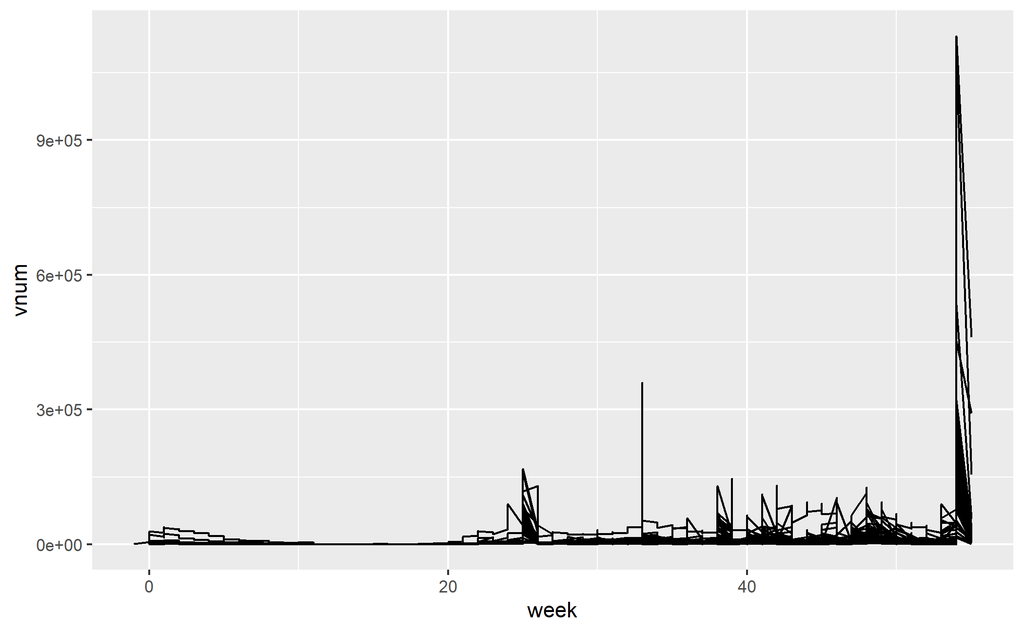

```r
test <- dataBA1 %>%
  filter(vnum < pop) %>%
  ggplot() + geom_line(aes(x = week, y = vnum, group = location))
test
```

### aggregate

aggregate the data by location, week, and dose

```r
dataBA1 <- dataBA1 %>%
  filter(vnum < pop) %>%
  group_by(country, location, week, pop, dose, resolution) %>%
  summarise(vnum = sum(vnum, na.rm = T)) %>%
  ungroup() %>%
  arrange(week) %>%
  group_by(location, dose) %>%
   mutate(vcum = cumsum(vnum)) %>%
  ungroup()
```

### test

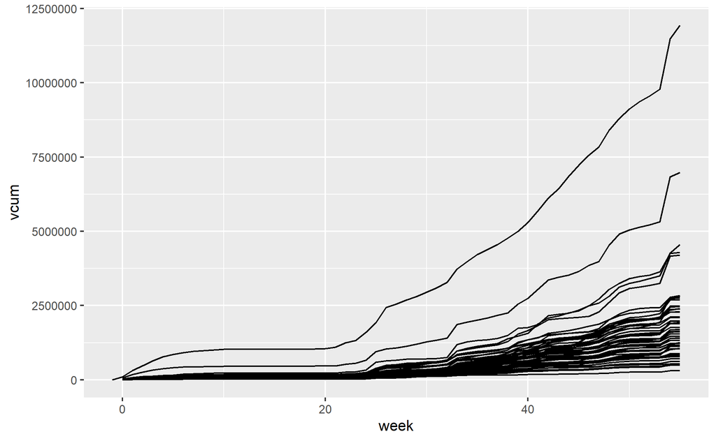

```r
test <- dataBA1 %>%
  ggplot() + geom_line(aes(x = week, y = vcum, group = location))
test
```

### percentage

calculate the percentage vaccinated

```r
## correct the population data with updated numbers from the covid site in August
popBA <- read_csv("BApopCorrect.csv") %>%
  mutate(location = gsub(" ", "", location))
dataBA1 <- dataBA1 %>%
  mutate(pop = NULL) %>%
  left_join(popBA) %>%
  mutate(vperc = vcum/pop* 100)
```

### test

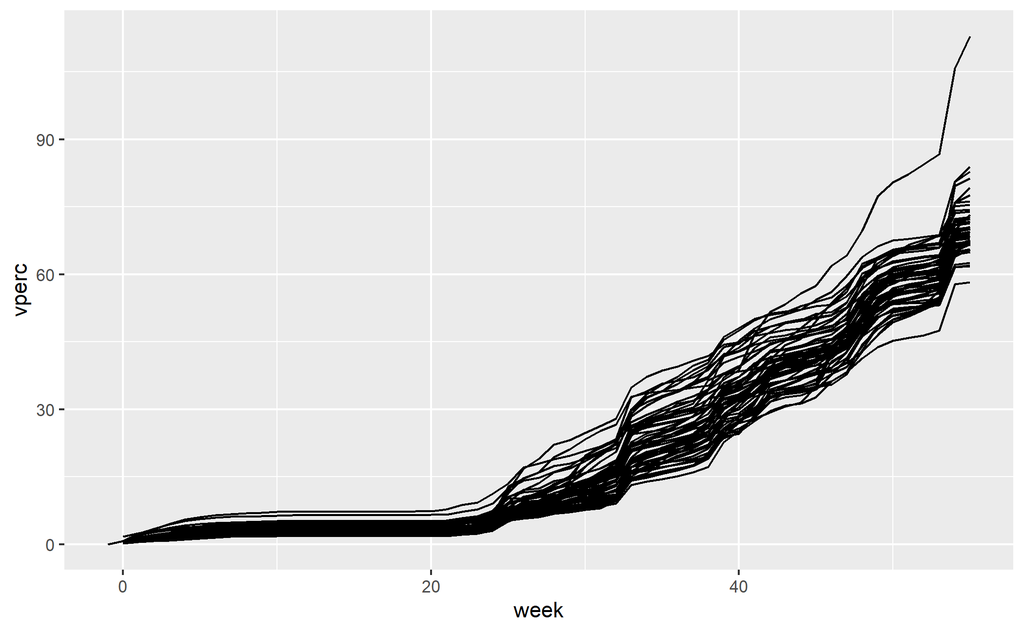

```r
test <- dataBA1 %>%
  ggplot() + geom_line(aes(x = week, y = vperc, group = location))
test
```

```r
test1 <- dataBA1 %>% filter(vperc > 100)
```

### get list of distinct locations

this code grabs a list of the distinct locations for which we have SES data AND vaccine data

```r
distinctBA <- dataBA2 %>%
  filter(measure == "income7") %>%
  inner_join(dataBA1) %>%
  filter(!is.na(vperc), !is.na(value)) %>%
  filter(dose == "partial") %>%
  select(location) %>%
  distinct()
```

### merge distinct with SES

this code pulls out of the SES data only those locations for which we also have vaccine data

```r
dataBA <- inner_join(dataBA2, distinctBA, by = c("location"))
```

### bin SES data

This code takes the SES data and cuts it into bins using cut_interval and ntile

```r
## grab the BA income data
dataBA <- dataBA %>%
  filter(measure == "income7") %>%
  mutate(nbin = ntile(x= value, n = 5)) %>%
  mutate(cbin = cut_interval(value, n = 5, labels = c("L",2,3,4, "H"), na.rm = T))

  dataBA$nbin[dataBA$nbin == 1] <- "L"
  dataBA$nbin[dataBA$nbin == 5] <- "H"
```

### merge vaccine with SES

merges the SES data with bins, to the vaccine data

```r
dataBA <- inner_join(dataBA1, dataBA, by = c("location", "country")) %>%
  group_by(location) %>%
  filter(!is.na(value), !all(is.na(vperc))) %>%
  ungroup()
```

### pivot

pivoting the SES bins into a column

```r
dataBA <- dataBA[c("country", "location","week", "vperc", "measure", "value", "cbin", "nbin")]%>%
  pivot_longer(cols = c("cbin", "nbin"), names_to = "bins", values_to = "binvalue")
```

### grid summary

computing average of location and bin, for H-L summaries

```r
gridBA <- dataBA %>%
  group_by(country, week, measure, bins, binvalue) %>%
  summarise(avg = mean(vperc)) %>%
  ungroup()
```

## US

Note: CDC data already starts at the first week of vaccination for the US, as far as I can identify (Dec 14 was first dose, data starts dec 13)

### fix the dips

```r
## this code looks for the first date where the leading vperc is lower than the current vperc and the difference is more than 2% (BAD). If this happens, it returns the date. If it doesn't happen, it returns NA.

## Then, it looks for the first date flagged. If no date is flagged, it returns the max date of the data. If any date is flagged, it returns the minimum such date.

## Finally, the code filters so that all the dates are before or equal to the first flagged date.

 ##dataUS1 <- dataUS1 %>%
   ##group_by(location, dose) %>%
  ## arrange(date) %>%
  ## mutate(dateP = if_else(vperc > lead(vperc), date, NA_Date_)) %>%
##  mutate(datePF = if_else(all(is.na(dateP)), max(date, na.rm = T), min(dateP, na.rm = T))) %>%
 ## filter(date <= datePF) %>%
## ungroup()

## na.rm warning in so many groups?
## in the ifelse, it tries to compute min(dateP), regardless of whether it actually uses it in the code. So, even if all(is.na(dateP)) is true (I have checked that this code works) it will still try to compute the minimum behind the scenes, which throws an error. Annoying, but I don't think there is an easy way to fix it; I thought about using a date far in the future instead of NA but this causes problems with when vperc = NA
```

### date to week

This code counts the weeks since vaccination started. It also chooses the vperc for max date in a week and counts that as the percentage vaccinated for that week

```r
dataUS1 <- dataUS1 %>%
  mutate(week = difftime(date, min(date, na.rm = T), units = "weeks")) %>%
  mutate( week = gsub(" weeks", "", week)) %>%
  mutate(week = as.integer(week)) %>%
  group_by(location, dose, week) %>%
  ## here we pick the max date in a week for a location, and filter out to just get the data for that date (i.e., we are pulling the most recent cumulative count for the week).
  filter(date == max(date, na.rm = T)) %>%
  ungroup() %>%
  mutate(date = NULL) %>%
  ## for each location and dose type, find the maximum week recorded and tag it
  group_by(location, dose) %>%
  mutate(weekm = max(week, na.rm = T)) %>%
  ungroup() %>%
  ## for each state, look at the minimum maxweek tagged for each state and filter anything before that. This way, we stop smoothing the state data once locations start dropping off, so we don't get dips
  group_by(state, dose) %>%
  filter(week <= min(weekm, na.rm = T)) %>%
  ungroup()
```

### inner join

```r
dataUS <- inner_join(dataUS1, dataUS2, by = c("location")) %>%
  filter(!is.na(vperc), !is.na(value))
```

### get list of distinct locations

where we have both vaccine and SES

```r
distinctUS <- dataUS %>%
  filter(!is.na(vperc), !is.na(value)) %>%
  filter(dose == "partial") %>%
  select(country, location, resolution, state, measure) %>%
  distinct() %>%
  count(country, resolution, measure, state) %>%
  add_column(continent = "North America")
```

### get list of state counts

This code filters out to get just the states with 20-100 counties

```r
distinctStateUS <- distinctUS %>%
  mutate(country = NULL, resolution = NULL) %>%
  filter(n < 100 & n > 20) %>%
  mutate(measure = NULL, n = NULL) %>%
  distinct()

##distinctStateUS$measure[distinctStateUS$measure == "income"] <- "income5"
##distinctStateUS$measure[distinctStateUS$measure == "poverty"] <- "income6"

## same set of states has over 100 observations for both income and poverty
```

### get list of state counts 2

This code filters out to get just the states with 12-20 counties

```r
distinctStateUS2 <- distinctUS %>%
  mutate(country = NULL, resolution = NULL) %>%
  filter(n < 21, n>11) %>%
  mutate(measure = NULL, n = NULL) %>%
  distinct()

##distinctStateUS$measure[distinctStateUS$measure == "income"] <- "income5"
##distinctStateUS$measure[distinctStateUS$measure == "poverty"] <- "income6"
```

```r
dataUS2 <- inner_join(dataUS, distinctStateUS2, by = c("state"))

dataUS <- inner_join(dataUS, distinctStateUS, by = c("state"))
```

### bin SES data

This code takes the United States SES data and cuts it into bins using cut_interval and ntile

```r
## grab the US income data
dataUSinc <- dataUS[c("location", "measure", "value", "state")] %>%
  distinct() %>%
  filter(measure == "income5") %>%
  group_by(state) %>%
  mutate(nbin = ntile(x= value, n = 5)) %>%
  mutate(cbin = cut_interval(value, n = 5, labels = c("L",2,3,4,"H"), na.rm = T)) %>%
  ungroup()

  dataUSinc$nbin[dataUSinc$nbin == 1] <- "L"
  dataUSinc$nbin[dataUSinc$nbin == 5] <- "H"

## grab the US poverty data
dataUSpov <- dataUS[c("location", "measure", "value", "state")] %>%
  distinct() %>%
  filter(measure == "income6") %>%
  group_by(state) %>%
  mutate(nbin = ntile(x= value, n = 5)) %>%
  mutate(cbin = cut_interval(value, n = 5, labels = c("H",4,3,2, "L"), na.rm = T)) %>%
  ungroup()

  dataUSpov$nbin[dataUSpov$nbin == 1] <- "H"
  dataUSpov$nbin[dataUSpov$nbin == 5] <- "L"

  ## bind them back together

  sesUS <- rbind(dataUSpov, dataUSinc)



  ## grab the US income data
dataUSinc2 <- dataUS2[c("location", "measure", "value", "state")] %>%
  distinct() %>%
  filter(measure == "income5") %>%
  group_by(state) %>%
  mutate(nbin = ntile(x= value, n = 3)) %>%
  mutate(cbin = cut_interval(value, n = 3, labels = c("L",2,"H"), na.rm = T)) %>%
  ungroup()

  dataUSinc2$nbin[dataUSinc2$nbin == 1] <- "L"
  dataUSinc2$nbin[dataUSinc2$nbin == 3] <- "H"

## grab the US poverty data
dataUSpov2 <- dataUS2[c("location", "measure", "value", "state")] %>%
  distinct() %>%
  filter(measure == "income6") %>%
  group_by(state) %>%
  mutate(nbin = ntile(x= value, n = 3)) %>%
  mutate(cbin = cut_interval(value, n = 3, labels = c("H",2, "L"), na.rm = T)) %>%
  ungroup()

  dataUSpov2$nbin[dataUSpov2$nbin == 1] <- "H"
  dataUSpov2$nbin[dataUSpov2$nbin == 3] <- "L"

  ## bind them back together

  ses2 <- rbind(dataUSpov2, dataUSinc2)

  sesUS <- rbind(sesUS, ses2)

  dataUS <- rbind(dataUS, dataUS2) %>%
    left_join(sesUS, by = c("location", "measure", "value", "state"))
```

### pivot

```r
dataUS <- dataUS[c("country","state", "location","week", "vperc", "measure", "value", "cbin", "nbin")]%>%
  pivot_longer(cols = c("cbin", "nbin"), names_to = "bins", values_to = "binvalue")
```

### grid summary

computing average of location and bin, for H-L summaries

```r
gridUS <- dataUS %>%
  group_by(country, week, measure, bins, binvalue, state) %>%
  summarise(avg = mean(vperc)) %>%
  ungroup()
```

### remove dud states

These states had data that was not possible, particularly Texas jumped from 0 vaccinations over months to a high percentage suddenly

```r
gridUS <- gridUS %>% filter(state != "CO"
                                   & state != "GA"
                                    & state != "MI" & state != "NE"
                                    & state != "NE" & state != "NM"
                                   & state != "OH" & state != "SD"
                                    & state != "TX" & state != "UT"
                                    & state != "VA" & state != "WV")
```

```r
## of these states, the ones in this set are still weird after despike()

##testplot <- gridUS %>% filter(state == "CO"
                                 ##   | state == "GA"
                                   ## | state == "MI" | state == "NE"
                              ##      | state == "NE" | state == "NM"
                                ##   | state == "OH" | state == "SD"
                              ##      | state == "TX" | state == "UT"
                              ##      | state == "VA" | state == "WV") %>%
  ## group_by(state, measure, binvalue) %>%
  ##filter(measure == "income5", bins == "nbin") %>%
  ##filter(binvalue == "H" | binvalue == "L") %>%
  ##mutate(avg = despike(
  ##avg,
  ##reference = "median",
  ##n = 1,
  ##k = 15,
  ##min = NA,
  ##max = NA,
  ##replace = "NA")
 ##) %>%
##  ggplot(aes(x = week, y = avg, group = binvalue)) + geom_line() + facet_wrap(~state)
## testplot
```

### view plots

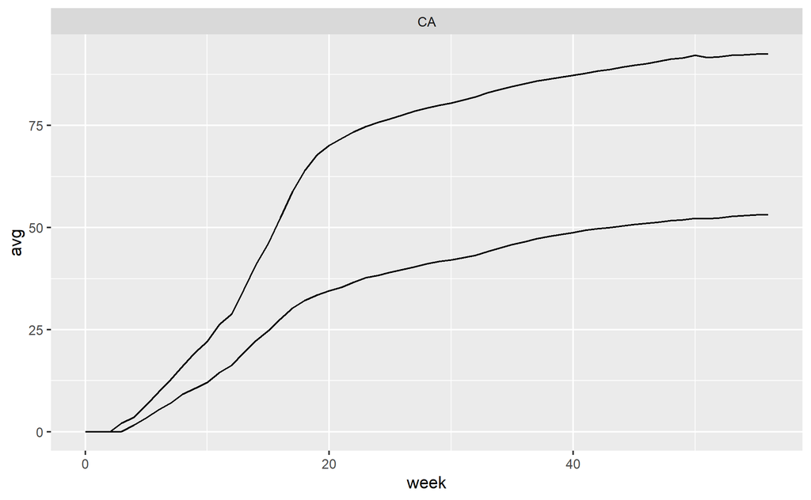

```r
plot <- gridUS %>% filter(bins == "nbin", measure == "income5", state == "CA") %>% filter(binvalue == "H" | binvalue == "L") %>%  ggplot() + geom_line(aes(x = week, y = avg, group = binvalue))  + facet_wrap(~state)
plot
```

## FRANCE

### date to week

Vaccination started in France on Dec. 27 2020 https://en.wikipedia.org/wiki/COVID-19_vaccination_in_France which is reflected in the data.

```r
start <- c("2020-12-27")

dataFr1 <- dataFr1 %>%
  mutate(week = difftime(date, as.Date(start, "%Y-%m-%d"), units = "weeks")) %>%
  mutate( week = gsub(" weeks", "", week)) %>%
  mutate(week = as.integer(week))
```

### aggregate/percentage

aggregate the data by location, week, and dose

```r
dataFr1 <- dataFr1 %>%
  group_by(country, resolution, pop, location, week, dose) %>%
  summarise(vsum = sum(vnum, na.rm = T)) %>%
  ungroup() %>%
  arrange(week) %>%
  group_by(location) %>%
  mutate(vcum = cumsum(vsum)) %>%
  ungroup() %>%
  mutate(vperc = 100*vcum/pop)
```

### get list of distinct locations

this code grabs a list of the distinct locations for which we have SES data AND vaccine data

```r
distinctFr <- dataFr2 %>%
  filter(measure == "income6" | measure == "income8") %>%
  inner_join(dataFr1) %>%
  group_by(location) %>%
  filter(!is.na(vperc), !is.na(value)) %>%
  ungroup() %>%
  filter(dose == "partial") %>%
  select(location, measure) %>%
  distinct()
```

### merge distinct with SES

this code pulls out of the SES data only those locations for which we also have vaccine data

```r
dataFr <- inner_join(dataFr2, distinctFr, by = c("location", "measure"))

dataFr$measure[dataFr$measure == "income6"] <- "poverty"
dataFr$measure[dataFr$measure == "income8"] <- "income"
```

### bin SES data

This code takes the SES data and cuts it into bins using cut_interval and ntile

```r
## income8 - median standard of living
dataFrinc <- dataFr %>%
  filter(measure == "income") %>%
  mutate(nbin = ntile(x= value, n = 5)) %>%
  mutate(cbin = cut_interval(value, n = 5, labels = c("L", 2, 3, 4,"H"), na.rm = T))

  dataFrinc$nbin[dataFrinc$nbin == 1] <- "L"
  dataFrinc$nbin[dataFrinc$nbin == 5] <- "H"

## income6 - poverty
dataFrpov <- dataFr %>%
  filter(measure == "poverty") %>%
  mutate(nbin = ntile(x= value, n = 5)) %>%
  mutate(cbin = cut_interval(value, n = 5, labels = c("H",4,3,2, "L"), na.rm = T))

  dataFrpov$nbin[dataFrpov$nbin == 1] <- "H"
  dataFrpov$nbin[dataFrpov$nbin == 5] <- "L"

    ## bind them back together

  dataFr <- rbind(dataFrpov, dataFrinc)
```

### merge vaccine with SES

merges the SES data with bins, to the vaccine data

```r
dataFr <- inner_join(dataFr1, dataFr, by = c("location", "country")) %>%
  group_by(location) %>%
  filter(!is.na(value), !all(is.na(vperc))) %>%
  ungroup()
```

### pivot

```r
dataFr <- dataFr[c("country", "location","week", "vperc", "measure", "value", "cbin", "nbin")]%>%
  pivot_longer(cols = c("cbin", "nbin"), names_to = "bins", values_to = "binvalue")
```

### grid summary

computing average of location and bin, for H-L summaries

```r
gridFr <- dataFr %>%
  group_by(country, week, measure, bins, binvalue) %>%
  summarise(avg = mean(vperc)) %>%
  ungroup()
```

## merge all the data

```r
dataGridUS <- gridUS %>%
  filter(binvalue == "L" | binvalue == "H")
##dataGrid <- rbind(gridPR, gridEc)
dataGrid <- rbind(gridPR, gridTW)
dataGrid <- rbind(dataGrid, gridKa)
dataGrid <- rbind(dataGrid, gridIs)

dataGrid <- rbind(dataGrid, gridPal)
dataGrid <- rbind(dataGrid, gridCV)
dataGrid <- rbind(dataGrid, gridSW)
dataGrid <- rbind(dataGrid, gridSP)

dataGrid <- rbind(dataGrid, gridRU)



dataGrid <- rbind(dataGrid, gridDK)


dataGrid <- rbind(dataGrid, gridAr)
dataGrid <- rbind(dataGrid, gridCZ)

dataGrid <- rbind(dataGrid, gridTR)

dataGrid <- rbind(dataGrid, gridFr)
dataGrid <- rbind(dataGrid, gridKE)
dataGrid <- rbind(dataGrid, gridMy)
dataGrid <- rbind(dataGrid, gridIN)
dataGrid <- rbind(dataGrid, gridJP)
dataGrid <- rbind(dataGrid, gridKO)
dataGrid <- rbind(dataGrid, gridES)
dataGrid <- rbind(dataGrid, gridSWI)
dataGrid <- rbind(dataGrid, gridUR)
dataGrid <- rbind(dataGrid, gridFI)
dataGrid <- rbind(dataGrid, gridCO)

dataGrid <- rbind(dataGrid, gridNO)

dataGrid <- rbind(dataGrid, gridIT)
dataGrid <- rbind(dataGrid, gridBA) %>%
  filter(binvalue == "L" | binvalue == "H")


dataMasterUS <- dataUS %>%
  filter(binvalue == "L" | binvalue == "H")
##dataMaster <- rbind(dataPR, dataEc)
dataMaster <- rbind(dataPR, dataTW)
dataMaster <- rbind(dataMaster, dataKa)
dataMaster <- rbind(dataMaster, dataTR)
dataMaster <- rbind(dataMaster, dataIs)
dataMaster <- rbind(dataMaster, dataPal)
dataMaster <- rbind(dataMaster, dataSP)

dataMaster <- rbind(dataMaster, dataAr)
dataMaster <- rbind(dataMaster, dataCV)

dataMaster <- rbind(dataMaster, dataRU)

dataMaster <- rbind(dataMaster, dataNO)

dataMaster <- rbind(dataMaster, dataCZ)
dataMaster <- rbind(dataMaster, dataDK)

dataMaster <- rbind(dataMaster, dataFr)
dataMaster <- rbind(dataMaster, dataKE)
dataMaster <- rbind(dataMaster, dataMy)
dataMaster <- rbind(dataMaster, dataIN)
dataMaster <- rbind(dataMaster, dataJP)
dataMaster <- rbind(dataMaster, dataKO)
dataMaster <- rbind(dataMaster, dataSW)

dataMaster <- rbind(dataMaster, dataES)
dataMaster <- rbind(dataMaster, dataSWI)
dataMaster <- rbind(dataMaster, dataUR)
dataMaster <- rbind(dataMaster, dataFI)
dataMaster <- rbind(dataMaster, dataCO)
dataMaster <- rbind(dataMaster, dataIT)
dataMaster <- rbind(dataMaster, dataBA) %>%
  filter(binvalue == "L" | binvalue == "H") %>%
  add_column(state = NA, .after = "country")

dataMaster <- rbind(dataMaster, dataMasterUS)
```

## make CSV

```r
makeCSV <- dataGrid %>%
  filter(bins == "nbin") %>%
  rename(bin = binvalue, value = avg) %>%
  mutate(bins = NULL)

makeCSVUS <- dataGridUS[c(1:7)] %>%
  filter(bins == "nbin") %>%
  rename(bin = binvalue, value = avg) %>%
  mutate(bins = NULL)

distinctUS <- dataUS %>%
  filter(!is.na(vperc), !is.na(value)) %>%
  select(country, location, measure, state) %>%
  distinct() %>%
  count(country, measure, state) %>%
  add_column(continent = "North America") %>%
  filter(measure == "income5")

distinctCO <- dataCO %>%
  filter(!is.na(vperc), !is.na(value)) %>%
  select(country, location, measure) %>%
  distinct() %>%
  count(country, measure) %>%
  add_column(continent = "South America")

distinctIT <- dataIT %>%
  filter(!is.na(vperc), !is.na(value)) %>%
  select(country, location, measure) %>%
  distinct() %>%
  count(country, measure) %>%
  add_column(continent = "Europe")

distinctKa <- dataKa %>%
  filter(!is.na(vperc), !is.na(value)) %>%
  select(country, location, measure) %>%
  distinct() %>%
  count(country, measure) %>%
  add_column(continent = "Asia")

distinctES <- dataES %>%
  filter(!is.na(vperc), !is.na(value)) %>%
  select(country, location, measure) %>%
  distinct() %>%
  count(country, measure) %>%
  add_column(continent = "Europe")

distinctCV <- dataCV %>%
  filter(!is.na(vperc), !is.na(value)) %>%
  select(country, location, measure) %>%
  distinct() %>%
  count(country, measure) %>%
  add_column(continent = "Africa")

distinctSW <- dataSW %>%
  filter(!is.na(vperc), !is.na(value)) %>%
  select(country, location, measure) %>%
  distinct() %>%
  count(country, measure) %>%
  add_column(continent = "Europe")

distinctPal <- dataPal %>%
  filter(!is.na(vperc), !is.na(value)) %>%
  select(country, location, measure) %>%
  distinct() %>%
  count(country, measure) %>%
  add_column(continent = "Asia")

distinctRU <- dataRU %>%
  filter(!is.na(vperc), !is.na(value)) %>%
  select(country, location, measure) %>%
  distinct() %>%
  count(country, measure) %>%
  add_column(continent = "Europe")

distinctUR <- dataUR %>%
  filter(!is.na(vperc), !is.na(value)) %>%
  select(country, location, measure) %>%
  distinct() %>%
  count(country, measure) %>%
  add_column(continent = "South America")

distinctFI <- dataFI %>%
  filter(!is.na(vperc), !is.na(value)) %>%
  select(country, location, measure) %>%
  distinct() %>%
  count(country, measure) %>%
  add_column(continent = "Europe")

distinctIs <- dataIs %>%
  filter(!is.na(vperc), !is.na(value)) %>%
  select(country, location, measure) %>%
  distinct() %>%
  count(country, measure) %>%
  add_column(continent = "Asia")

distinctNO <- dataNO %>%
  filter(!is.na(vperc), !is.na(value)) %>%
  select(country, location, measure) %>%
  distinct() %>%
  count(country, measure) %>%
  add_column(continent = "Europe")


distinctAr <- dataAr %>%
  filter(!is.na(vperc), !is.na(value)) %>%
  select(country, location, measure) %>%
  distinct() %>%
  count(country, measure) %>%
  add_column(continent = "South America")

distinctDK <- dataDK %>%
  filter(!is.na(vperc), !is.na(value)) %>%
  select(country, location, measure) %>%
  distinct() %>%
  count(country, measure) %>%
  add_column(continent = "Europe")

distinctSP <- dataSP %>%
  filter(!is.na(vperc), !is.na(value)) %>%
  select(country, location, measure) %>%
  distinct() %>%
  count(country, measure) %>%
  add_column(continent = "Europe")

distinctCZ <- dataCZ %>%
  filter(!is.na(vperc), !is.na(value)) %>%
  select(country, location, measure) %>%
  distinct() %>%
  count(country, measure) %>%
  add_column(continent = "Europe")

distinctSWI <- dataSWI %>%
  filter(!is.na(vperc), !is.na(value)) %>%
  select(country, location, measure) %>%
  distinct() %>%
  count(country, measure) %>%
  add_column(continent = "Europe") %>%
  filter(measure == "Socasst")

distinctPR <- dataPR2 %>%
  filter(measure == "income5" | measure == "income6") %>%
  inner_join(dataPR1) %>%
  filter(!is.na(vperc), !is.na(value)) %>%
  ## no dose data
  select(country, location, resolution, measure) %>%
  distinct() %>%
  count(country, resolution, measure) %>%
  add_column(continent = "North America") %>% filter(measure == "income5")
distinctFr <- dataFr2 %>%
  inner_join(dataFr1) %>%
  filter(!is.na(vperc), !is.na(value)) %>%
  filter(dose == "partial") %>%
  select(country, location, resolution, measure) %>%
  distinct() %>%
  count(country, resolution, measure) %>%
  add_column(continent = "Europe") %>% filter(measure == "income8" | measure == "income")
distinctFr$measure[distinctFr$measure == "income6"] <- "poverty"
distinctFr$measure[distinctFr$measure == "income8"] <- "income"


##distinctEc <- dataEc2 %>%
##  mutate(population = NULL) %>%
##  inner_join(dataEc1) %>%
##  filter(!is.na(vperc), !is.na(value)) %>%
##  select(country, location, resolution, measure) %>%
##  distinct() %>%
##  count(country, resolution, measure) %>%
##  add_column(continent = "South America")

distinctBA <- dataBA2 %>%
  filter(measure == "income7") %>%
  inner_join(dataBA1) %>%
  filter(!is.na(vperc), !is.na(value)) %>%
  filter(dose == "partial") %>%
  select(country, location, resolution, measure) %>%
  distinct() %>%
  count(country, resolution, measure) %>%
  add_column(continent = "Asia")
distinctKE <- dataKE2 %>%
  inner_join(dataKE1) %>%
  filter(!is.na(vperc), !is.na(value)) %>%
  filter(dose == "partial") %>%
  select(country, location, resolution, measure) %>%
  distinct() %>%
  count(country, resolution, measure) %>%
  add_column(continent = "Africa") %>%
  filter(measure == "poverty")
distinctKO <- dataKO2 %>%
  inner_join(dataKO1) %>%
  filter(!is.na(vperc), !is.na(value)) %>%
  select(country, location, resolution, measure) %>%
  distinct() %>%
  count(country, resolution, measure) %>%
  add_column(continent = "Asia") %>%
  filter(measure == "income2")
distinctJP <- dataJP2 %>%
  inner_join(dataJP1) %>%
  filter(dose == 1) %>%
  filter(!is.na(vperc), !is.na(value)) %>%
  select(country, location, measure) %>%
  distinct() %>%
  count(country, measure) %>%
  add_column(continent = "Asia")
distinctIN <- dataIN2 %>%
  inner_join(dataIN1) %>%
  filter(!is.na(vperc), !is.na(value)) %>%
  filter(dose == "partial") %>%
  select(country, location, measure) %>%
  distinct() %>%
  count(country, measure) %>%
  add_column(continent = "Asia")
distinctTW <- dataTW2 %>%
  inner_join(dataTW1) %>%
  filter(!is.na(vperc), !is.na(value)) %>%
  filter(dose == "partial") %>%
  select(country, location, measure) %>%
  distinct() %>%
  count(country, measure) %>%
  add_column(continent = "Asia")
distinctMy <- dataMy2 %>%
  inner_join(dataMy1) %>%
  filter(!is.na(vperc), !is.na(value)) %>%
  filter(dose == "partial") %>%
  select(country, location, resolution, measure) %>%
  distinct() %>%
  count(country, resolution, measure)%>%
  add_column(continent = "Asia")
distinctTR <- dataTR2 %>%
  inner_join(dataTR1) %>%
  filter(!is.na(vperc), !is.na(value)) %>%
  filter(dose == "partial") %>%
  select(country, location, measure) %>%
  distinct() %>%
  count(country, measure)%>%
  add_column(continent = "Asia")
distinctA <- rbind(distinctPR, distinctFr)
##distinctA <- rbind(distinctA, distinctEc)
distinctA <- rbind(distinctA, distinctMy)
distinctA <-  rbind(distinctA, distinctBA)
distinctA <-  rbind(distinctA, distinctKO)
distinctA <- rbind(distinctA, distinctKE) %>%
  mutate(resolution = NULL)
distinctA <- rbind(distinctA, distinctJP)
distinctA <- rbind(distinctA, distinctCO)
distinctA <- rbind(distinctA, distinctDK)

distinctA <-  rbind(distinctA, distinctIs)
distinctA <- rbind(distinctA, distinctTW)
distinctA <- rbind(distinctA, distinctIN)
distinctA <- rbind(distinctA, distinctES)
distinctA <- rbind(distinctA, distinctSWI)
distinctA <- rbind(distinctA, distinctPal)
distinctA <- rbind(distinctA, distinctUR)
distinctA <- rbind(distinctA, distinctFI)
distinctA <- rbind(distinctA, distinctIT)
distinctA <- rbind(distinctA, distinctKa)
distinctA <- rbind(distinctA, distinctAr)
distinctA <- rbind(distinctA, distinctCZ)
distinctA <- rbind(distinctA, distinctSW)
distinctA <- rbind(distinctA, distinctSP)

distinctA <- rbind(distinctA, distinctCV)
distinctA <- rbind(distinctA, distinctNO)
distinctA <- rbind(distinctA, distinctRU)




distinctA <- rbind(distinctA, distinctTR) %>%
  add_column(state = NA, .before = "n")

distinctUS <- distinctUS %>% mutate(resolution = NULL)

 distinctA <- rbind(distinctA, distinctUS)

 makeCSV <- makeCSV %>%
   add_column(state = NA, .after = "country")
 makeCSVUS <- makeCSVUS[c(1,4,2,3,5,6)]
makeCSV <- rbind(makeCSV, makeCSVUS)

 makeCSV <- inner_join(makeCSV, distinctA, by = c("country", "state", "measure"))

 makeCSV <- makeCSV %>%
  rename(numberLoc = n) %>%
   mutate(resolution = NULL)
```

### clean the dips in the data

```r
makeCSV <- makeCSV %>%
  group_by(country, state, measure, bin) %>%
  mutate(value = despike(
  value,
  reference = "median",
  n = 1,
  k = 15,
  min = NA,
  max = NA,
  replace = "NA")
)
```

### test plot

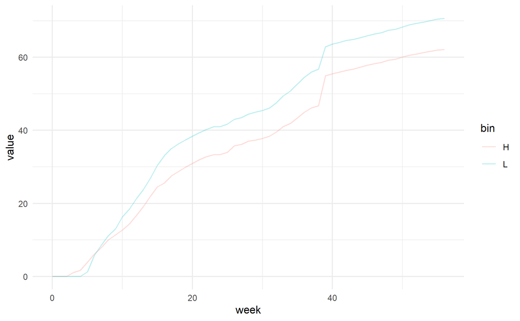

```r
plot <- makeCSV %>%
  filter(state == "AL") %>%
ggplot(aes(x = week, y = value)) + geom_line(aes(color = bin, group = bin), alpha=.25) + theme_minimal()
plot
```

### save

```r
write.csv(makeCSV,"C:/Users/sophi/Box/Vaccine_inequity/Data/final/makeCSV2.csv", row.names = FALSE)

write.csv(dataMaster,"C:/Users/sophi/Box/Vaccine_inequity/Data/final/loc2.csv", row.names = FALSE)
```